# EntregaFinal

## Introducción

Durante este curso se realizó un análisis demográfico de la población del estado de Yucatán, para ello usamos los datos de los censos realizados por el INEGI durante el 2010 y 2020. Así mismo, durante el presente trabajo se valuará la calidad de la información bajo los siguientes índices:

- Whipple
- Mayers
- INU

Además, se buscará analizar la población de Yucatán en aspectos como:

- Migración
- Mortalidad
- Natalidad

Explicando cada uno de los resultados durante el desarrollo del código.

```python
import pandas as pd
import numpy as np
from ast import iter_child_nodes
import matplotlib.pyplot as plt
import seaborn as sns
```

```python
w10 = pd.read_excel(r'/content/2010_Whipple.xls') #Excel con los datos para whipple 2010
w20 = pd.read_excel(r'/content/2020_Whipple.xls') #Excel con los datos para whipple 2020
m10 = pd.read_excel(r'/content/2010_Myers.xls') #Excel con los datos para Myers 2010
m20 = pd.read_excel(r'/content/2020_Myers.xls') #Excel con los datos para Myers 2020
inu10 = pd.read_excel(r'/content/2010_INU.xls') #Excel con los datos para INU 2010
inu20 = pd.read_excel(r'/content/2020_INU.xls') #Excel con los datos para INU 2020
pq10 = pd.read_excel(r'/content/PQ_2010.xlsx') #Excel con los datos para piramide quinquenal 2010
pq20 = pd.read_excel(r'/content/PQ_2020.xlsx') #Excel con los datos para piramide quinquenal 2020
pi10 = pd.read_excel(r'/content/PI_2010.xls') #Excel con los datos para piramide individual 2010
pi20 = pd.read_excel(r'/content/PI_2020.xls') #Excel con los datos para piramide individual 2020
```

```python
w10 = w10.drop(columns=['Total'], axis = 1)
w20 = w20.drop(columns=['Total'], axis = 1)
```

```python
w10 = w10.rename(columns={'Unnamed: 0': 'Edad'})
w20 = w20.rename(columns={'Unnamed: 0': 'Edad'})
```

```python
w10.columns == w20.columns
```

```
array([ True,  True,  True])
```

```python
#@title Numerador

#2010
suma_q_h_10 = sum(w10.iloc[25:61:5, 1].values) #hombres
suma_q_m_10 = sum(w10.iloc[25:61:5, 2].values) #mujeres

#2020
suma_q_h_20 = sum(w20.iloc[25:61:5, 1].values) #hombres
suma_q_m_20 = sum(w20.iloc[25:61:5, 2].values) #mujeres
```

```python
#@title Denominador

#2010
suma_h_23_62_10 = sum(w10.iloc[23:63 , 1].values) #hombres
suma_m_23_62_10 = sum(w10.iloc[23:63 , 2].values) #mujeres

#2020
suma_h_23_62_20 = sum(w20.iloc[23:63 , 1].values) #hombres
suma_m_23_62_20 = sum(w20.iloc[23:63 , 2].values) #mujeres
```

```python
#@title Indices de Whipple

#Whipple 2010 para hombres y mujeres
whipple10_h = round((((5)*suma_q_h_10)/(suma_h_23_62_10))*100, 3)
whipple10_m = round((((5)*suma_q_m_10)/(suma_m_23_62_10))*100, 3)

#Whipple 2020 para hombres y mujeres
whipple20_h = round((((5)*suma_q_h_20)/(suma_h_23_62_20))*100, 3)
whipple20_m = round((((5)*suma_q_m_20)/(suma_m_23_62_20))*100, 3)

#El 3 al final indica que redondearemos los resultados a dos decimales.
```

```python
#@title Resultado de los índices

print(f'El índice de Whipple de hombres en el 2010 en Yucatán es: {whipple10_h}')
print(f'El índice de Whipple de mujeres en el 2010 en Yucatán es: {whipple10_m}')
print(f'El índice de Whipple de hombres en el 2020 en Yucatán es: {whipple20_h}')
print(f'El índice de Whipple de mujeres en el 2020 en Yucatán es: {whipple20_m}')
```

```
El índice de Whipple de hombres en el 2010 en Yucatán es: 113.905
El índice de Whipple de mujeres en el 2010 en Yucatán es: 112.606
El índice de Whipple de hombres en el 2020 en Yucatán es: 113.741
El índice de Whipple de mujeres en el 2020 en Yucatán es: 113.551
```

El índice de Whipple nos dice lo siguiente:

- $ [100, 105) \rightarrow$ La información es excelente, los datos recabados son precisos
- $ [105, 110) \rightarrow$ Los datos son relativamente buenos
- $ [110, 125) \rightarrow$ Los datos son aproximados pero carecen de exactitud.
- $ [125, 175) \rightarrow$ Los datos son malos y de baja calidad
- $ [175,500] \rightarrow$ Los datos recabados son pésimo

Lo que nos indica que nuestros datos son aproximados, pero carecen de exactitud, pues se encuentran en el intervalo [110, 125).

Razones por las cuales esto sucede: Más allá de la tendencia a redondear la edad a múltiplos de 5, Yucatán ha sido, históricamente, una entidad con registros incompletos de nacimientos. Ésto promueve que las personas den edades aproximadas, más no las reales, Scielo. Además la información se mantuvo idéntica respecto a calidad entre los registros de 2010 y 2020 y entre hombre y mujeres, los hombres brindan información menos confiable respecto a las mujeres

```python
#@title Índice de Myers
m10 = m10.drop(columns=['Total'], axis = 1)
m20 = m20.drop(columns=['Total'], axis = 1)
```

```python
m10 = m10.rename(columns={'Unnamed: 0': 'Edad'})
m20 = m20.rename(columns={'Unnamed: 0': 'Edad'})
```

```python
class Myer:
  def __init__(self, df1, df2):
    self.df1 = df1
    self.df2 = df2

  def calcular_myers(self):
    indices_myers = []
    for df in [self.df1, self.df2]:
      for k in range(1,3):
        suma_ajs_Pjs = []

        for j in range(10):

            aj = j + 1
            aj_prima = 9 - j

            # Definimos las poblaciones
            P_Aj = sum(df.iloc[10+j : 61+j : 10 , k].values)
            P_Bj = sum(df.iloc[20+j : 71+j : 10 , k].values)

            suma_aj_Pj = (aj * P_Aj) + (aj_prima * P_Bj)
            suma_ajs_Pjs.append(suma_aj_Pj)

        # Construcción de las Mj's

        Mj_s = []

        for j in suma_ajs_Pjs:
            Mj = ((j/sum(suma_ajs_Pjs))-(1/10))* 100
            Mj_s.append(Mj)

        IM = 0

        for Mj in Mj_s:
            IM += abs(Mj)

        indices_myers.append(round(IM, 3))
        #print(Mj_s)

    return indices_myers[0], indices_myers[1], indices_myers[2], indices_myers[3]
```

```python
#@title Resultados

myers = Myer(m10, m20)
im_h_2010, im_m_2010, im_h_2020, im_m_2020 = myers.calcular_myers()

print(f'El índice de Myers para hombres en el 2010 en Yucatán es: {im_h_2010}')
print(f'El índice de Myers para mujeres en el 2010 en Yucatán es: {im_m_2010}')
print(f'El índice de Myers para hombres en el 2020 en Yucatán es: {im_h_2020}')
print(f'El índice de Myers para mujeres en el 2020 en Yucatán es: {im_m_2020}')
```

```
El índice de Myers para hombres en el 2010 en Yucatán es: 6.222
El índice de Myers para mujeres en el 2010 en Yucatán es: 5.676
El índice de Myers para hombres en el 2020 en Yucatán es: 6.803
El índice de Myers para mujeres en el 2020 en Yucatán es: 6.246
```

De acuerdo con el índice de Myer:

- $[0, 4.99] \rightarrow$ La información es excelente, los datos recabados son precisos
- $[5, 14.99] \rightarrow$ La información es buena, pero con algunas inconsistencias
- $[15, 29.99] \rightarrow$ La información es mala
- $ 30$ o $+ \rightarrow$ La información es pésima y carece de precisión

Nuestra información se encuentra dentro del segundo rango en todos los resultados, por lo que es buena, pero con algunas inconsistencias, esto se debe a que la población tiene un poco de tendencia a declarar su edad con numeros con ciertas terminaciones, las que mas destacan son las terminaciones 0 y 1, la primera por ser la más preferida y la segunda por ser la menos preferida. Además la información empeoró un poco de 2010 a 2020 según este índice, ésto podría deberse a que la población envejeció, haciendo que la edad específica importe menos dado una cantidad alta de años. Además, entre hombres y mujeres, los hombres brindan información menos confiable respecto a las mujeres

```python
#@title Índice de Naciones Unidas
inu10 = inu10.drop(columns=['Total'], axis = 1)
inu20 = inu20.drop(columns=['Total'], axis = 1)
```

```python
class NacionesUnidas:
  def __init__(self, df1, df2):
    self.df1 = df1
    self.df2 = df2

  def calcular_inu(self):
    indices_inu = []
    for df in [self.df1, self.df2]:
      CEH = []
      CEM = []
      deltaIM = []

      for i in range(1,16):
          pobH_presente = df.iloc[:, 1].values[i]
          pobH_pasada = df.iloc[:, 1].values[i-1]
          pobH_futura = df.iloc[:, 1].values[i+1]

          pobM_presente = df.iloc[:, 2].values[i]
          pobM_pasada = df.iloc[:, 2].values[i-1]
          pobM_futura = df.iloc[:, 2].values[i+1]

          IM_presente = ((pobH_presente)/(pobM_presente))*100
          IM_pasado = ((pobH_pasada)/(pobM_pasada))*100

          coef_edad_H_changing = abs(((2*pobH_presente)/(pobH_pasada + pobH_futura))-1)*100
          CEH.append(coef_edad_H_changing)
          coef_edad_M_changing = abs(((2*pobM_presente)/(pobM_pasada + pobM_futura))-1)*100
          CEM.append(coef_edad_M_changing)
          delta_IM_changing = abs(IM_presente - IM_pasado)
          deltaIM.append(delta_IM_changing)

      INU = (1/15)*(sum(CEH)+sum(CEM)+ (3*sum(deltaIM)))
      indices_inu.append(round(INU, 4))

    return indices_inu[0], indices_inu[1]
```

```python
inu = NacionesUnidas(inu10, inu20)

inu_2010, inu_2020 = inu.calcular_inu()

print(f'El Índice de Naciones Unidas para el 2010 en Yucatán es: {inu_2010}')
print(f'El Índice de Naciones Unidas para el 2020 en Yucatán es: {inu_2020}')
```

```
El Índice de Naciones Unidas para el 2010 en Yucatán es: 12.0229
El Índice de Naciones Unidas para el 2020 en Yucatán es: 7.6938
```

Recordemos los Índices de las Naciones Unidas: La escala de valores de este índice es la siguiente:

- Menos de $20 \rightarrow$ La información es satisfactoria
- De $20$ a $40 \rightarrow$ La información es de calidad intermedia
- Más de $40 \rightarrow$ La información es deficiente

La información del estado de Yucatán es satisfactoria, además de que del censo del 2010 al censo del 2020 se mejoró la calidad de la información.

```python
#@title Pirámides individuales
pi10 = pi10.rename(columns={'Unnamed: 0': 'Edad'})
pi20 = pi20.rename(columns={'Unnamed: 0': 'Edad'})
```

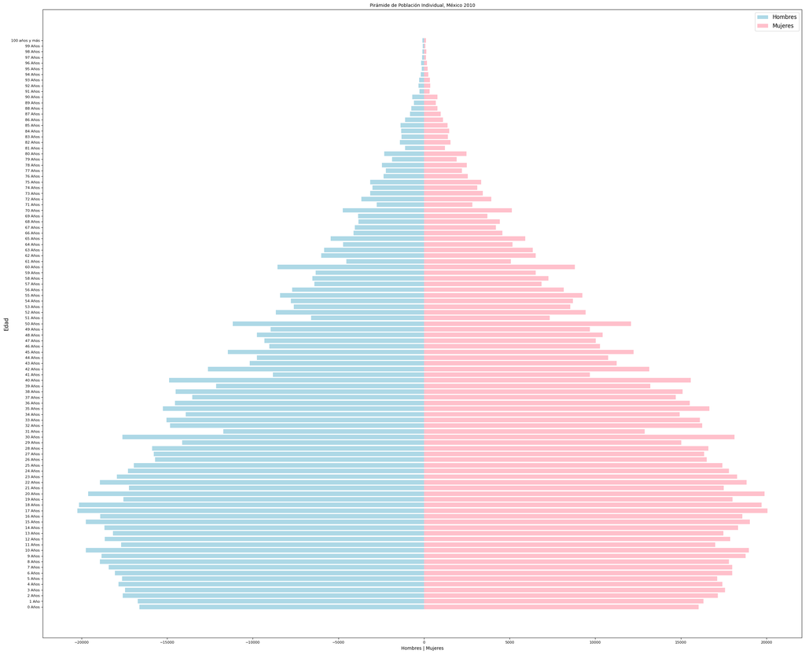

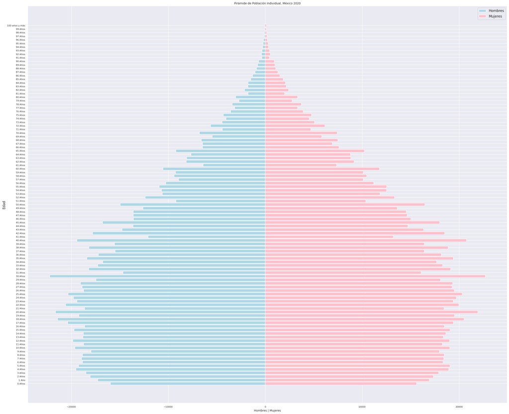

```python
#Primer gráfica
fig, ax = plt.subplots(figsize = (30, 25))
ax.barh(pi10['Edad'], - pi10.iloc[:, 1], color = 'lightblue', label = 'Hombres')
ax.barh(pi10['Edad'], pi10.iloc[:, 2], color = 'pink', label = 'Mujeres')

ax.set_title(f'Pirámide de Población Individual, México 2010', fontsize =10)
ax.set_xlabel('Hombres | Mujeres', fontsize = 10)


ax.set_ylabel('Edad', fontsize = 12)

ax.legend(fontsize = 12)

ax.tick_params(axis = 'both', which = 'major', labelsize = 8)

#Segunda gráfica
sns.set(style = "darkgrid")

fig, ax = plt.subplots(figsize = (30, 25))

ax.barh(pi20['Edad'], - pi20.iloc[:, 1], color = 'lightblue', label = 'Hombres')
ax.barh(pi20['Edad'], pi20.iloc[:, 2], color = 'pink', label = 'Mujeres')

ax.set_title(f'Pirámide de Población Individual, México 2020', fontsize =10)
ax.set_xlabel('Hombres | Mujeres', fontsize = 10)



ax.set_ylabel('Edad', fontsize = 12)

ax.legend(fontsize = 12)

ax.tick_params(axis = 'both', which = 'major', labelsize = 8)

plt.show()
```

Análisis de las pirámides individuales

En la del 2010 se observan abultamientos en las edades quinquenales, princialmente las terminadas en 0, además se observa un posible abultamiento pequeño en las edades de 17, 18 22, 38 42 y 58 años en las del 2020 no se observan cambios significativos a simple vista a excepción de una reducción de abultamiento en las edades de 17 y 58 años y un leve aumento en el abultamiento en las edades de 12, 32, 52 y 72 años. Según el índice de whipple, los abultamientos en las edades quinquenales se deben a una calidad de información no resaltante puesto que la gente prefiere declarar su edad en multiplos de 5, el índice de Myers concuerda con el de whipple, con la diferencia de que significativamente se prefiere declarar la edad en múltiplos de 10 que en múltiplos de 5; los abultamientos leves observados en las piramides respecto a las edades terminadas en 2 y 8 se deben a una preferencia positiva, mientras que todas las edades no quinquenales y terminadas en 2 u 8 tienen preferencia negativa

```python
#@title Pirámides quinquenales
pq10 = pq10.drop(columns=['Total'], axis = 1)
pq20 = pq20.drop(columns=['Total'], axis = 1)
```

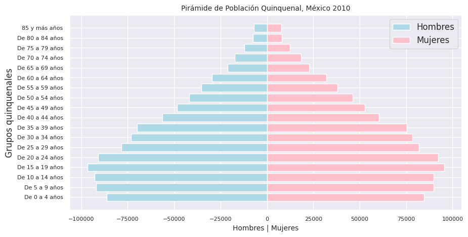

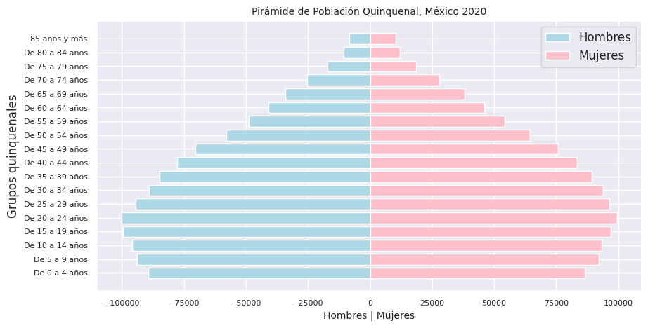

```python
#Primer gráfica
fig, ax = plt.subplots(figsize = (10, 5))
ax.barh(pq10['Edad'], - pq10.iloc[:, 1], color = 'lightblue', label = 'Hombres')
ax.barh(pq10['Edad'], pq10.iloc[:, 2], color = 'pink', label = 'Mujeres')

ax.set_title(f'Pirámide de Población Quinquenal, México 2010', fontsize =10)
ax.set_xlabel('Hombres | Mujeres', fontsize = 10)



ax.set_ylabel('Grupos quinquenales', fontsize = 12)

ax.legend(fontsize = 12)

ax.tick_params(axis = 'both', which = 'major', labelsize = 8)

#Segunda gráfica
sns.set(style = "darkgrid")

fig, ax = plt.subplots(figsize = (10, 5))

ax.barh(pq20['Edad'], - pq20.iloc[:, 1], color = 'lightblue', label = 'Hombres')
ax.barh(pq20['Edad'], pq20.iloc[:, 2], color = 'pink', label = 'Mujeres')

ax.set_title(f'Pirámide de Población Quinquenal, México 2020', fontsize =10)
ax.set_xlabel('Hombres | Mujeres', fontsize = 10)



ax.set_ylabel('Grupos quinquenales', fontsize = 12)

ax.legend(fontsize = 12)

ax.tick_params(axis = 'both', which = 'major', labelsize = 8)

plt.show()
```

Análisis de las pirámides quinquenales

En 2010 la mayor parte de la población se concentra entre los 5 y 24 años, siendo la población de 15 a 19 años la más numerosas y en 2020 la mayor parte de la población se concentra entre los 5 y 29 años, siendo la de 20 a 24 años la más numerosa, estos cambios quizá se deben a que pasaron 10 años y se recorrieron las poblaciones. Se tiene una pirámide estacionaria en ambas, pirámide propia de una población que hace poco tuvo una disminución en la mortalidad y aumento en la natalidad, aunque no es muy pronunciado el grueso de la pirámide.

```python
pb_10 = pd.read_excel(r'/content/2010_INU.xls')
pb_20 = pd.read_excel(r'/content/2020_INU.xls')
```

```python
pb_10 = pb_10.drop(columns=['Total'])
pb_20 = pb_20.drop(columns=['Total'])
```

```python
pb_10.iloc[18,2] == pb_10['Mujeres'][18]
```

```
True
```

## Prorrateo de los censos de 2010 y 2020

```python
# POBLACIÓN NO ESPECIFICADA

pbNE_H2010 = pb_10.iloc[18,1]
pbNE_M2010 = pb_10.iloc[18,2]

pbNE_H2020 = pb_20.iloc[18,1]
pbNE_M2020 = pb_20.iloc[18,2]



# POBLACIÓN TOTAL POR CADA SEXO
pbT_hombres2010 = sum(pb_10.iloc[:,1])
pbT_mujeres2010 = sum(pb_10.iloc[:,2])

pbT_hombres2020 = sum(pb_20.iloc[:,1])
pbT_mujeres2020 = sum(pb_20.iloc[:,2])
```

```python
# Factor de prorrateo para sexo y año

FP_hombres2010 = 1 + (pbNE_H2010/(pbT_hombres2010 - pbNE_H2010))
FP_mujeres2010 = 1 + (pbNE_M2010/(pbT_mujeres2010 - pbNE_M2010))

FP_hombres2020 = 1 + (pbNE_H2020/(pbT_hombres2020 - pbNE_H2020))
FP_mujeres2020 = 1 + (pbNE_M2020/(pbT_mujeres2020 - pbNE_M2020))
```

```python
H2010_prorrateada = round(pb_10.iloc[:18, 1] * FP_hombres2010)
M2010_prorrateada = round(pb_10.iloc[:18, 2] * FP_mujeres2010)

H2020_prorrateada = round(pb_20.iloc[:18, 1] * FP_hombres2020)
M2020_prorrateada = round(pb_20.iloc[:18, 2] * FP_mujeres2020)
```

```python
pb_10.iloc[:18, 0]
```

|  | Edad |
| --- | --- |
| 0 | De 0 a 4 años |
| 1 | De 5 a 9 años |
| 2 | De 10 a 14 años |
| 3 | De 15 a 19 años |
| 4 | De 20 a 24 años |
| 5 | De 25 a 29 años |
| 6 | De 30 a 34 años |
| 7 | De 35 a 39 años |
| 8 | De 40 a 44 años |
| 9 | De 45 a 49 años |
| 10 | De 50 a 54 años |
| 11 | De 55 a 59 años |
| 12 | De 60 a 64 años |
| 13 | De 65 a 69 años |
| 14 | De 70 a 74 años |
| 15 | De 75 a 79 años |
| 16 | De 80 a 84 años |
| 17 | 85 y más años |

**dtype:** object

```python
Edad_Actualizada =  pb_10.iloc[:18, 0]
```

```python
pob2010_prorrateada = pd.DataFrame({'Edad':Edad_Actualizada, 'Hombres':H2010_prorrateada, 'Mujeres':M2010_prorrateada})
pob2020_prorrateada = pd.DataFrame({'Edad':Edad_Actualizada, 'Hombres':H2020_prorrateada, 'Mujeres':M2020_prorrateada})
```

```python
pob2010_prorrateada.to_excel('pob2010_prorrateada.xlsx', index = False)
pob2020_prorrateada.to_excel('pob2020_prorrateada.xlsx', index = False)
```

Tablas que miden la diferencia entre la población original con la población prorrateada:

```python
P_COMPARACION_2010 = pb_10
P_COMPARACION_2020 = pb_20

P_COMPARACION_2010['Hombres'] = pob2010_prorrateada['Hombres'] - pb_10['Hombres']
P_COMPARACION_2010['Mujeres'] = pob2010_prorrateada['Mujeres'] - pb_10['Mujeres']

P_COMPARACION_2020['Hombres'] = pob2020_prorrateada['Hombres'] - pb_20['Hombres']
P_COMPARACION_2020['Mujeres'] = pob2020_prorrateada['Mujeres'] - pb_20['Mujeres']

print(P_COMPARACION_2010)
print(P_COMPARACION_2020)
```

```
               Edad  Hombres  Mujeres
0     De 0 a 4 años    567.0    540.0
1     De 5 a 9 años    604.0    573.0
2   De 10 a 14 años    611.0    573.0
3   De 15 a 19 años    635.0    610.0
4   De 20 a 24 años    599.0    590.0
5   De 25 a 29 años    516.0    524.0
6   De 30 a 34 años    481.0    501.0
7   De 35 a 39 años    460.0    481.0
8   De 40 a 44 años    370.0    386.0
9   De 45 a 49 años    319.0    337.0
10  De 50 a 54 años    275.0    295.0
11  De 55 a 59 años    233.0    243.0
12  De 60 a 64 años    195.0    204.0
13  De 65 a 69 años    140.0    146.0
```

[output cut: 25 more lines]

Se incorpora más población de los no especificados a las edades más jóvenes, ésto podría deberse a que la población más vieja es menos numerosa, se observa que hay una notable diferencia entre el prorrateo de 2010 al de 2020, ésto se debe a que la población no especificada se redujo

## Corrección de los censos por el método de 1/16

```python
pob_prorr_10 = pd.read_excel(r'/content/pob2010_prorrateada.xlsx')
pob_prorr_20 = pd.read_excel(r'/content/pob2020_prorrateada.xlsx')
```

```python
pob_prorr_10['Hombres'][2] == pob_prorr_10.iloc[2,1]
```

```
True
```

```python
pob_1_16_H_2010 = []
pob_1_16_H_2020 = []
pob_1_16_M_2010 = []
pob_1_16_M_2020 = []

for i in range(2, 15):

    # PARA HOMBRES
    form_H2010 = ( - pob_prorr_10.iloc[i-2, 1] + (4 * pob_prorr_10.iloc[i-1, 1]) + (10 * pob_prorr_10.iloc[i, 1]) + (4 * pob_prorr_10.iloc[i+1, 1]) - pob_prorr_10.iloc[i+2, 1] ) / 16
    pob_1_16_H_2010.append(form_H2010)

    form_H2020 = ( - pob_prorr_20.iloc[i-2, 1] + (4 * pob_prorr_20.iloc[i-1, 1]) + (10 * pob_prorr_20.iloc[i, 1]) + (4 * pob_prorr_20.iloc[i+1, 1]) - pob_prorr_20.iloc[i+2, 1] ) / 16
    pob_1_16_H_2020.append(form_H2020)


    # PARA MUJERES
    form_M2010 = ( - pob_prorr_10.iloc[i-2, 2] + (4 * pob_prorr_10.iloc[i-1, 2]) + (10 * pob_prorr_10.iloc[i, 2]) + (4 * pob_prorr_10.iloc[i+1, 2]) - pob_prorr_10.iloc[i+2, 2] ) / 16
    pob_1_16_M_2010.append(form_M2010)

    form_M2020 = ( - pob_prorr_20.iloc[i-2, 2] + (4 * pob_prorr_20.iloc[i-1, 2]) + (10 * pob_prorr_20.iloc[i, 2]) + (4 * pob_prorr_20.iloc[i+1, 2]) - pob_prorr_20.iloc[i+2, 2] ) / 16
    pob_1_16_M_2020.append(form_M2020)
```

```python
pob_1_16_H_2010, pob_1_16_M_2010, pob_1_16_H_2020, pob_1_16_M_2020
```

```
([94743.625,
  96350.0625,
  90862.875,
  80173.25,
  74095.0625,
  68609.625,
  57991.9375,
  48582.5625,
  42009.3125,
  35833.5,
  29179.6875,
  22220.8125,
  16958.875],
 [91861.3125,
  95009.75,
  92110.125,
  83718.25,
  79181.0625,
  73747.5625,
  62361.5625,
  52811.875,
  46019.8125,
  38825.875,
  31339.25,
  23847.6875,
  17965.5625],
 [96547.375,
  99504.3125,
  99639.9375,
  95040.3125,
  89636.4375,
  84631.0625,
  78317.75,
  69574.9375,
  58629.0,
  48756.9375,
  41190.25,
  33915.9375,
  25549.25],
 [94128.875,
  97143.5,
  98963.6875,
  97121.0625,
  93783.25,
  89470.4375,
  83663.875,
  75501.0625,
  64851.0625,
  54538.0625,
  46087.875,
  37724.9375,
  27957.8125])
```

```python
pob2010_1_16 = pob_prorr_10.copy()
pob2020_1_16 = pob_prorr_20.copy()
```

```python
# Para hombres
pob2010_1_16.iloc[2:15, 1] = pob_1_16_H_2010
pob2020_1_16.iloc[2:15, 1] = pob_1_16_H_2020

# Para mujeres
pob2010_1_16.iloc[2:15, 2] = pob_1_16_M_2010
pob2020_1_16.iloc[2:15, 2] = pob_1_16_M_2020
```

```python
pob2010_1_16 = round(pob2010_1_16)
pob2020_1_16 = round(pob2020_1_16)

pob2010_1_16
```

|  | Edad | Hombres | Mujeres |
| --- | --- | --- | --- |
| 0 | De 0 a 4 años | 86786.0 | 85048.0 |
| 1 | De 5 a 9 años | 92496.0 | 90268.0 |
| 2 | De 10 a 14 años | 94744.0 | 91861.0 |
| 3 | De 15 a 19 años | 96350.0 | 95010.0 |
| 4 | De 20 a 24 años | 90863.0 | 92110.0 |
| 5 | De 25 a 29 años | 80173.0 | 83718.0 |
| 6 | De 30 a 34 años | 74095.0 | 79181.0 |
| 7 | De 35 a 39 años | 68610.0 | 73748.0 |
| 8 | De 40 a 44 años | 57992.0 | 62362.0 |
| 9 | De 45 a 49 años | 48583.0 | 52812.0 |
| 10 | De 50 a 54 años | 42009.0 | 46020.0 |
| 11 | De 55 a 59 años | 35834.0 | 38826.0 |
| 12 | De 60 a 64 años | 29180.0 | 31339.0 |
| 13 | De 65 a 69 años | 22221.0 | 23848.0 |
| 14 | De 70 a 74 años | 16959.0 | 17966.0 |
| 15 | De 75 a 79 años | 12150.0 | 12567.0 |
| 16 | De 80 a 84 años | 7540.0 | 8188.0 |
| 17 | 85 y más años | 7081.0 | 7861.0 |

```python
pob2010_1_16.to_excel('/content/pob2010_1_16.xlsx', index = False)
pob2020_1_16.to_excel('/content/pob2020_1_16.xlsx', index = False)
```

```python
P_COMPARACION_a = pd.DataFrame({'Edad':pob2020_1_16['Edad']})
P_COMPARACION_a['Hombres'] = pob2020_1_16['Hombres'] - pob2010_1_16['Hombres']
P_COMPARACION_a['Mujeres'] = pob2020_1_16['Mujeres'] - pob2010_1_16['Mujeres']


print(P_COMPARACION_a)
```

```
               Edad  Hombres  Mujeres
0     De 0 a 4 años   2698.0   1744.0
1     De 5 a 9 años   1562.0   2102.0
2   De 10 a 14 años   1803.0   2268.0
3   De 15 a 19 años   3154.0   2134.0
4   De 20 a 24 años   8777.0   6854.0
5   De 25 a 29 años  14867.0  13403.0
6   De 30 a 34 años  15541.0  14602.0
7   De 35 a 39 años  16021.0  15722.0
8   De 40 a 44 años  20326.0  21302.0
9   De 45 a 49 años  20992.0  22689.0
10  De 50 a 54 años  16620.0  18831.0
11  De 55 a 59 años  12923.0  15712.0
12  De 60 a 64 años  12010.0  14749.0
13  De 65 a 69 años  11695.0  13877.0
14  De 70 a 74 años   8590.0   9992.0
15  De 75 a 79 años   5042.0   5912.0
16  De 80 a 84 años   2997.0   3788.0
17    85 y más años   1207.0   2514.0
```

# Modelo de crecimiento exponencial

$$ P(t) = P(0) e^{rt} $$

```python
pb10_suavizada = pd.read_excel(r'/content/pob2010_1_16.xlsx')
pb20_suavizada = pd.read_excel(r'/content/pob2020_1_16.xlsx')
```

```python
r_mujeres = np.log(pb20_suavizada['Mujeres'] / pb10_suavizada['Mujeres'])/10
r_hombres = np.log(pb20_suavizada['Hombres'] / pb10_suavizada['Hombres'])/10
```

```python
tasa_crecimiento = pd.DataFrame({'Edad': pb20_suavizada['Edad'], 'Tasa Hombres (r)':r_hombres, 'Tasa Mujeres (r)':r_mujeres})
```

# Gráfica con crecimiento poblacional de hombres y mujeres del año 2010 al 2020 en Yucatán

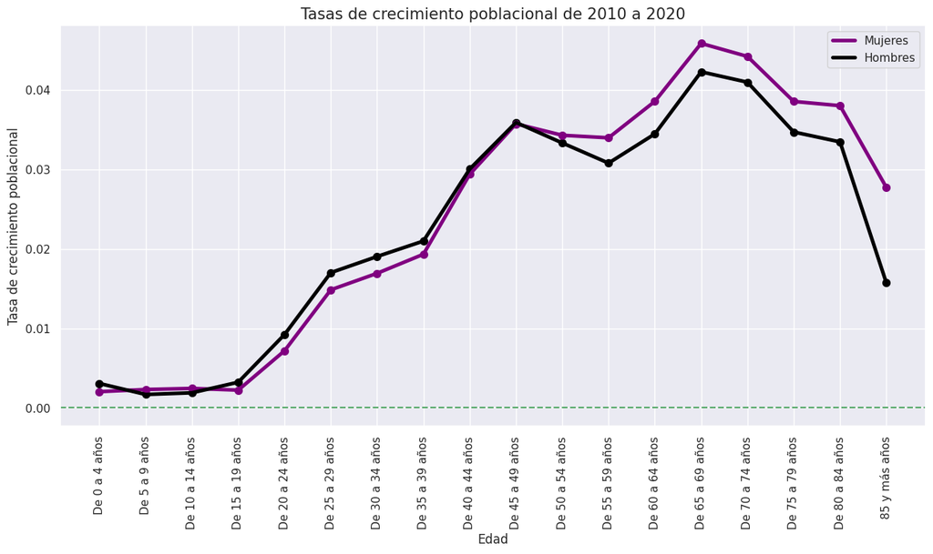

```python
sns.set_theme(style = 'darkgrid')
sns.lineplot(data = tasa_crecimiento, x = 'Edad', y = 'Tasa Mujeres (r)', color = 'purple', linewidth = 3.5, label = 'Mujeres')
sns.lineplot(data = tasa_crecimiento, x = 'Edad', y = 'Tasa Hombres (r)', color = 'black', linewidth = 3.5, label = 'Hombres').axhline(0, ls='--', c='g')
plt.gcf().set_size_inches(15,7)
plt.ylabel('Tasa de crecimiento poblacional')
plt.xticks(rotation = 'vertical')
plt.title('Tasas de crecimiento poblacional de 2010 a 2020', fontsize=15)


plt.scatter(tasa_crecimiento['Edad'], tasa_crecimiento['Tasa Hombres (r)'], color='black', marker='o', s=50)
plt.scatter(tasa_crecimiento['Edad'], tasa_crecimiento['Tasa Mujeres (r)'], color='purple', marker='o', s=50)

plt.show()
```

# Gráfica del crecimiento poblacional de hombres del año 2010 al 2020 en Yucatán

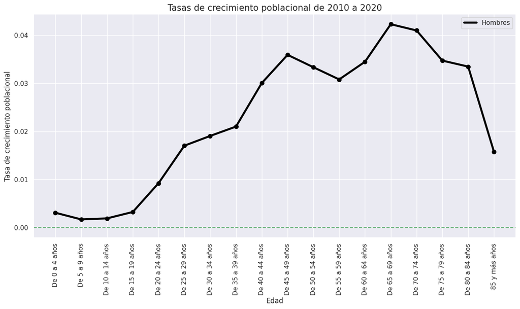

```python
sns.set_theme(style = 'darkgrid')

sns.lineplot(data = tasa_crecimiento, x = 'Edad', y = 'Tasa Hombres (r)', color = 'black', linewidth = 3.5, label = 'Hombres').axhline(0, ls='--', c='g')
plt.gcf().set_size_inches(15,7)
plt.ylabel('Tasa de crecimiento poblacional')
plt.xticks(rotation = 'vertical')
plt.title('Tasas de crecimiento poblacional de 2010 a 2020', fontsize=15)


plt.scatter(tasa_crecimiento['Edad'], tasa_crecimiento['Tasa Hombres (r)'], color='black', marker='o', s=50)


plt.show()
```

En hombres, los grupos que crecen a mayor ritmo son los de 60 a 79 años mas el quinquenio de 45 a 49, siendo el quinquenio de 65 a 69 el más numeroso. Los grupos que crecen a menor ritmo son los que van de 0 a 19 años, siendo el de 5 a 9 años el de menor ritmo

## Gráfica de crecimiento poblacional de mujeres del año 2010 al 2020 en Yucatán

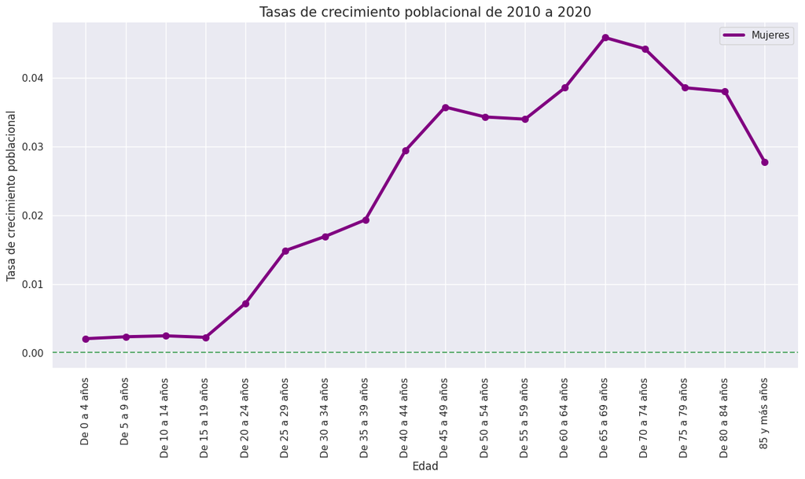

```python
sns.set_theme(style = 'darkgrid')
sns.lineplot(data = tasa_crecimiento, x = 'Edad', y = 'Tasa Mujeres (r)', color = 'purple', linewidth = 3.5, label = 'Mujeres').axhline(0, ls='--', c='g')

plt.gcf().set_size_inches(15,7)
plt.ylabel('Tasa de crecimiento poblacional')
plt.xticks(rotation = 'vertical')
plt.title('Tasas de crecimiento poblacional de 2010 a 2020', fontsize=15)



plt.scatter(tasa_crecimiento['Edad'], tasa_crecimiento['Tasa Mujeres (r)'], color='purple', marker='o', s=50)

plt.show()
```

En mujeres, los grupos que crecen a mayor ritmo son los de 60 a 79 años, siendo el quinquenio de 65 a 69 el más numeroso. Los grupos que crecen a menor ritmo son los que ven de0 a 19 años, siendo todos los quinquenios de estas edades muy similares en su ritmo de crecimiento

# Población a mitad de año

Tomando en cuenta que hemos tomado que el censo de 2010 se realizó el 12 de junio del mismo año, y el censo del 2020 se realizó el 15 de marzo del año 2020, podemos formular lo siguiente:

```python
pobMitad2010_H = ((pb10_suavizada['Hombres'])*np.e**(tasa_crecimiento['Tasa Hombres (r)']*(19/365))).round()
pobMitad2010_M = ((pb10_suavizada['Mujeres'])*np.e**(tasa_crecimiento['Tasa Mujeres (r)']*(19/365))).round()

pobMitad2020_H = ((pb20_suavizada['Hombres'])*np.e**(tasa_crecimiento['Tasa Hombres (r)']*(108/365))).round()
pobMitad2020_M = ((pb20_suavizada['Mujeres'])*np.e**(tasa_crecimiento['Tasa Mujeres (r)']*(108/365))).round()
```

```python
#Lo convertimos en DF
mitadAnio_2010 = pd.DataFrame({'Edad':pb10_suavizada['Edad'], 'Hombres':pobMitad2010_H, 'Mujeres':pobMitad2010_M})
mitadAnio_2020 = pd.DataFrame({'Edad':pb20_suavizada['Edad'], 'Hombres':pobMitad2020_H, 'Mujeres':pobMitad2020_M})
```

```python
mitadAnio_2010.to_excel('mitadAnio_2010.xlsx', index = False)
mitadAnio_2020.to_excel('mitadAnio_2020.xlsx', index = False)
```

Tablas que miden la diferencia entre la población corregida con el método de 1/16 con la población a mitad de año:

```python
P_COMPARACION_2010['Hombres'] = pob2010_1_16['Hombres'] - mitadAnio_2010['Hombres']
P_COMPARACION_2010['Mujeres'] = pob2010_1_16['Mujeres'] - mitadAnio_2010['Mujeres']

P_COMPARACION_2020['Hombres'] = pob2020_1_16['Hombres'] - mitadAnio_2020['Hombres']
P_COMPARACION_2020['Mujeres'] = pob2020_1_16['Mujeres'] - mitadAnio_2020['Mujeres']
print(P_COMPARACION_2010)
print(P_COMPARACION_2020)
```

```
               Edad  Hombres  Mujeres
0     De 0 a 4 años    -14.0     -9.0
1     De 5 a 9 años     -8.0    -11.0
2   De 10 a 14 años     -9.0    -12.0
3   De 15 a 19 años    -16.0    -11.0
4   De 20 a 24 años    -44.0    -34.0
5   De 25 a 29 años    -71.0    -65.0
6   De 30 a 34 años    -73.0    -70.0
7   De 35 a 39 años    -75.0    -74.0
8   De 40 a 44 años    -91.0    -95.0
9   De 45 a 49 años    -91.0    -98.0
10  De 50 a 54 años    -73.0    -82.0
11  De 55 a 59 años    -57.0    -69.0
12  De 60 a 64 años    -52.0    -63.0
13  De 65 a 69 años    -49.0    -57.0
```

[output cut: 25 more lines]

La población a mitad de año es mayor que la observada en el censo corregido, esto se debe a que los censos fueron realizados antes de la mitad de año y la población está creciendo, especialmente en el censo de 2020

# Tasa Bruta de Mortalidad

```python
def_2010 = pd.read_excel('/content/defunciones 2010.xlsx')
def_2020 = pd.read_excel('/content/defunciones 2020.xlsx')

pob_mitad_anio_2010 = pd.read_excel(r'/content/mitadAnio_2010.xlsx')
pob_mitad_anio_2020 = pd.read_excel(r'/content/mitadAnio_2020.xlsx')
```

```python
tasa_bruta_mort_hombre_2010 = ( sum(def_2010['Hombre']) / sum(pob_mitad_anio_2010['Hombres']) ) * 1000
tasa_bruta_mort_mujer_2010 = ( sum(def_2010['Mujer']) / sum(pob_mitad_anio_2010['Mujeres']) ) * 1000

num_globo = sum(def_2010['Hombre'])+sum(def_2010['Mujer'])
denom_global = sum(pob_mitad_anio_2010['Hombres']) + sum(pob_mitad_anio_2010['Mujeres'])

tasa_bruta_mort_2010 = (num_globo/denom_global) * 1000
```

```python
tasa_bruta_mort_hombre_2020 = ( sum(def_2020['Hombre']) / sum(pob_mitad_anio_2020['Hombres']) ) * 1000
tasa_bruta_mort_mujer_2020 = ( sum(def_2020['Mujer']) / sum(pob_mitad_anio_2020['Mujeres']) ) * 1000

num_globo = sum(def_2020['Hombre'])+sum(def_2020['Mujer'])
denom_global = sum(pob_mitad_anio_2020['Hombres']) + sum(pob_mitad_anio_2020['Mujeres'])

tasa_bruta_mort_2020 = (num_globo/denom_global) * 1000
```

```python
tasa_bruta_mort = pd.DataFrame({'Año':[2010, 2020], 'Tasa bruta de mortalidad en hombres':[tasa_bruta_mort_hombre_2010, tasa_bruta_mort_hombre_2020], 'Tasa bruta de mortalidad en mujeres':[tasa_bruta_mort_mujer_2010, tasa_bruta_mort_mujer_2020], 'Tasa bruta de mortalidad global':[tasa_bruta_mort_2010, tasa_bruta_mort_2020]})
```

```python
tasa_bruta_mort
```

|  | Año | Tasa bruta de mortalidad en hombres | Tasa bruta de mortalidad en mujeres | Tasa bruta de mortalidad global |
| --- | --- | --- | --- | --- |
| 0 | 2010 | 6.226243 | 5.134987 | 5.672503 |
| 1 | 2020 | 8.967260 | 6.624614 | 7.775417 |

Nótese que durante el 2010 por cada 1000 hombres fallecieron 6 personas, de igual manera durante ese mismo año de cada 1000 mujeres fallecieron 5.

Del mismo modo, durante el 2020 de cada 1000 hombres fallecieron al rededor de 9, y por cada 1000 mujeres fallecieron aproximadamente 7 personas.

Hablando de la tasa global, debemos observar que la mortalidad pasó de 5.6 fallecidos por cada 1000 habitantes a 7.77.

Algunas de las principales razones por las cuales ésto pudo haber sucedido es que:

- Envejeció la población
- Incremento de la violencia en el país
- COVID-19

# Gráfico de muertes de menores de un año neonatal y posneonatal

```python
mort_infantil_2010 = pd.read_excel(r"/content/mortalidad infantil 2010.xlsx")
mort_infantil_2020 = pd.read_excel(r"/content/mortalidad infantil 2020.xlsx")
```

```python
mort_infantil_2010.iloc[:4, 1]
```

|  | Hombre |
| --- | --- |
| 0 | 105 |
| 1 | 9 |
| 2 | 12 |
| 3 | 4 |

**dtype:** int64

```python
mort_neonat_hombre_2010 = sum(mort_infantil_2010.iloc[:4, 1])
mort_neonat_hombre_2020 = sum(mort_infantil_2020.iloc[:4, 1])
```

```python
mort_neonat_mujer_2010 = sum(mort_infantil_2010.iloc[:4, 2])
mort_neonat_mujer_2020 = sum(mort_infantil_2020.iloc[:4, 2])
```

```python
mort_postneonat_hombre_2010 = sum(mort_infantil_2010.iloc[4:, 1])
mort_postneonat_hombre_2020 = sum(mort_infantil_2020.iloc[4:, 1])
```

```python
mort_postneonat_mujer_2010 = sum(mort_infantil_2010.iloc[4:, 2])
mort_postneonat_mujer_2020 = sum(mort_infantil_2020.iloc[4:, 2])
```

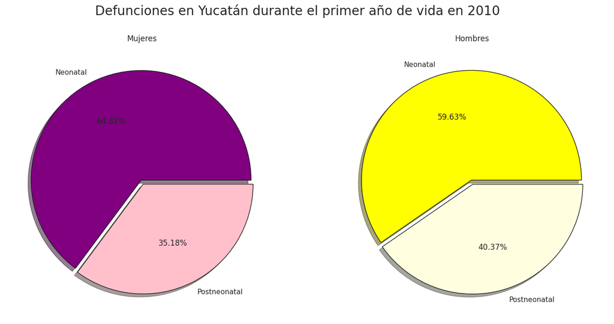

```python
categ = ['Neonatal', 'Postneonatal']

# MUJERES
conteos_mujer_2010 = [mort_neonat_mujer_2010, mort_postneonat_mujer_2010]

# HOMBRES
conteo_hombre_2010 = [mort_neonat_hombre_2010, mort_postneonat_hombre_2010]

color_mujer = ('purple', 'pink')
color_hombre = ('yellow', 'lightyellow')
separacion = (0.02, 0.02)
contorno = {"linewidth":1, "edgecolor":"k"}
fig, axes = plt.subplots(1, 2, figsize = (17, 8))
fig.suptitle('Defunciones en Yucatán durante el primer año de vida en 2010', fontsize = 20)
axes[0].set_title('Mujeres')
axes[1].set_title('Hombres')

axes[0].pie(conteos_mujer_2010, labels = categ, colors = color_mujer, explode=separacion, wedgeprops = contorno, autopct = "%1.2f%%", shadow = True)
axes[1].pie(conteo_hombre_2010, labels = categ, colors = color_hombre, explode=separacion, wedgeprops = contorno, autopct = "%1.2f%%", shadow = True)
plt.show()
```

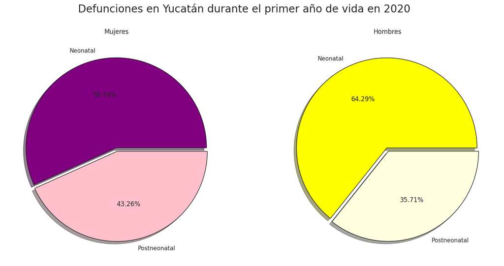

```python
# MUJERES
conteos_mujer_2020 = [mort_neonat_mujer_2020, mort_postneonat_mujer_2020]

# HOMBRES
conteo_hombre_2020 = [mort_neonat_hombre_2020, mort_postneonat_hombre_2020]

color_mujer = ('purple', 'pink')
color_hombre = ('yellow', 'lightyellow')
separacion = (0.02, 0.02)
contorno = {"linewidth":1, "edgecolor":"k"}
fig, axes = plt.subplots(1, 2, figsize = (17, 8))
fig.suptitle('Defunciones en Yucatán durante el primer año de vida en 2020', fontsize = 20)
axes[0].set_title('Mujeres')
axes[1].set_title('Hombres')

axes[0].pie(conteos_mujer_2020, labels = categ, colors = color_mujer, explode=separacion, wedgeprops = contorno, autopct = "%1.2f%%", shadow = True)
axes[1].pie(conteo_hombre_2020, labels = categ, colors = color_hombre, explode=separacion, wedgeprops = contorno, autopct = "%1.2f%%", shadow = True)
plt.show()
```

Nótese que durante el 2010 la mayoría de muestes de personas menores a un año fue neonatal, mientras que durante el 2020, principalmente con las mujeres, las defunciones en etapa postneonatal aumentó considerablemente.

Por otro lado la cantidad de muertes de hombres en la etapa postneonatal disminuyó.

# Tasas específicas de mortalidad

```python
def_2010 = pd.read_excel('/content/defunciones 2010.xlsx')
def_2020 = pd.read_excel('/content/defunciones 2020.xlsx')
```

```python
def_2010 = def_2010.rename({'Hombre':'Hombres', 'Mujer':'Mujeres'}, axis=1)
def_2020 = def_2020.rename({'Hombre':'Hombres', 'Mujer':'Mujeres'}, axis=1)
```

```python
def_0_4_hombre_2010 = sum(def_2010.iloc[:2,1])
def_0_4_mujer_2010 = sum(def_2010.iloc[:2,2])
def_0_4_hombre_2020 = sum(def_2020.iloc[:2,1])
def_0_4_mujer_2020 = sum(def_2020.iloc[:2,2])
```

```python
tasa_esp_mort_0_4_hombre_2010 = def_0_4_hombre_2010/pob_mitad_anio_2010.iloc[0,1]
tasa_esp_mort_0_4_mujer_2010 = def_0_4_mujer_2010/pob_mitad_anio_2010.iloc[0,2]
tasa_esp_mort_0_4_hombre_2020 = def_0_4_hombre_2020/pob_mitad_anio_2020.iloc[0,1]
tasa_esp_mort_0_4_mujer_2020 = def_0_4_mujer_2020/pob_mitad_anio_2020.iloc[0,2]
```

```python
tasa_esp_mort_resto_hombre_2010 = def_2010.iloc[2:,1].values / pob_mitad_anio_2010.iloc[1:,1].values
tasa_esp_mort_resto_mujer_2010 = def_2010.iloc[2:,2].values / pob_mitad_anio_2010.iloc[1:,2].values
tasa_esp_mort_resto_hombre_2020 = def_2020.iloc[2:,1].values / pob_mitad_anio_2020.iloc[1:,1].values
tasa_esp_mort_resto_mujer_2020 = def_2020.iloc[2:,2].values / pob_mitad_anio_2020.iloc[1:,2].values
```

```python
tasa_esp_mort_hombre_2010 = np.append(tasa_esp_mort_0_4_hombre_2010, tasa_esp_mort_resto_hombre_2010)
tasa_esp_mort_mujer_2010 = np.append(tasa_esp_mort_0_4_mujer_2010, tasa_esp_mort_resto_mujer_2010)
tasa_esp_mort_hombre_2020 = np.append(tasa_esp_mort_0_4_hombre_2020, tasa_esp_mort_resto_hombre_2020)
tasa_esp_mort_mujer_2020 = np.append(tasa_esp_mort_0_4_mujer_2020, tasa_esp_mort_resto_mujer_2020)
```

```python
tasa_esp_mort_2010 = pd.DataFrame({'Edad':pob_mitad_anio_2010['Edad'], 'TEM Hombres':tasa_esp_mort_hombre_2010, 'TEM Mujeres':tasa_esp_mort_mujer_2010})
tasa_esp_mort_2020 = pd.DataFrame({'Edad':pob_mitad_anio_2020['Edad'], 'TEM Hombres':tasa_esp_mort_hombre_2020, 'TEM Mujeres':tasa_esp_mort_mujer_2020})
```

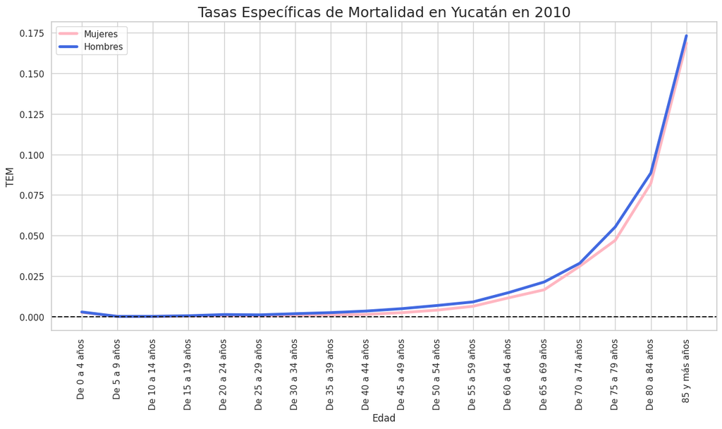

```python
sns.set_theme(style = 'whitegrid')
sns.lineplot(data = tasa_esp_mort_2010, x ='Edad', y = 'TEM Mujeres', color = 'lightpink', linewidth = 3.5, label = 'Mujeres')
sns.lineplot(data = tasa_esp_mort_2010, x ='Edad', y = 'TEM Hombres', color = 'royalblue', linewidth = 3.5, label = 'Hombres').axhline(0, ls='--', c='k')

plt.gcf().set_size_inches(15,7)
plt.ylabel('TEM')
plt.title('Tasas Específicas de Mortalidad en Yucatán en 2010', fontsize = 18)
plt.xticks(rotation = 'vertical')
plt.show()
```

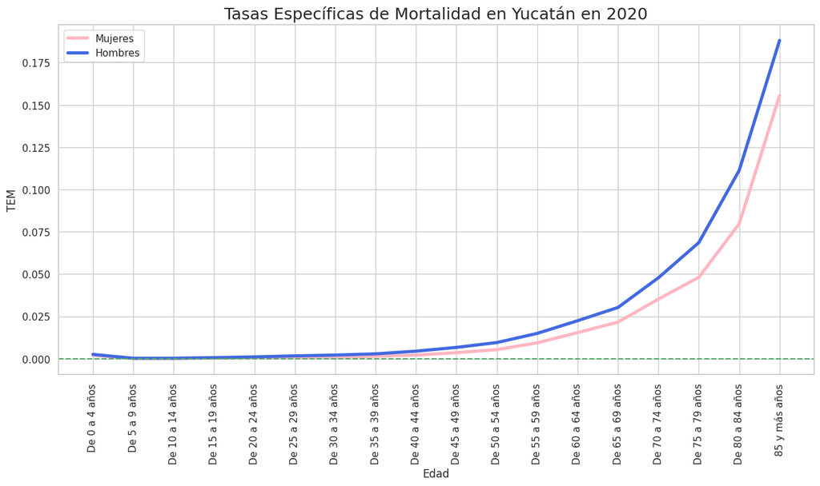

```python
sns.set_theme(style = 'whitegrid')
sns.lineplot(data = tasa_esp_mort_2020, x ='Edad', y = 'TEM Mujeres', color = 'lightpink', linewidth = 3.5, label = 'Mujeres')
sns.lineplot(data = tasa_esp_mort_2020, x ='Edad', y = 'TEM Hombres', color = 'royalblue', linewidth = 3.5, label = 'Hombres').axhline(0, ls='--', c='g')

plt.gcf().set_size_inches(15,7)
plt.title('Tasas Específicas de Mortalidad en Yucatán en 2020', fontsize = 18)
plt.ylabel('TEM')
plt.xticks(rotation = 'vertical')
plt.show()
```

```python
copia_tasa_esp_mort_2010 = tasa_esp_mort_2010.copy()
copia_tasa_esp_mort_2020 = tasa_esp_mort_2020.copy()

copia_tasa_esp_mort_2010['TEM Hombres'] = np.log(tasa_esp_mort_2010['TEM Hombres'])
copia_tasa_esp_mort_2010['TEM Mujeres'] = np.log(tasa_esp_mort_2010['TEM Mujeres'])
copia_tasa_esp_mort_2020['TEM Hombres'] = np.log(tasa_esp_mort_2020['TEM Hombres'])
copia_tasa_esp_mort_2020['TEM Mujeres'] = np.log(tasa_esp_mort_2020['TEM Mujeres'])
```

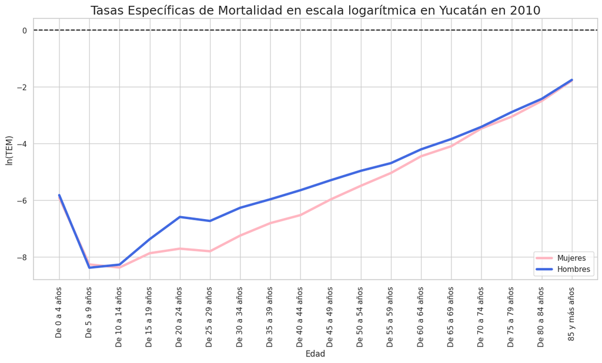

```python
sns.set_theme(style = 'whitegrid')
sns.lineplot(data = copia_tasa_esp_mort_2010, x ='Edad', y = 'TEM Mujeres', color = 'lightpink', linewidth = 3.5, label = 'Mujeres')
sns.lineplot(data = copia_tasa_esp_mort_2010, x ='Edad', y = 'TEM Hombres', color = 'royalblue', linewidth = 3.5, label = 'Hombres').axhline(0, ls='--', c='k')

plt.gcf().set_size_inches(15,7)
plt.title('Tasas Específicas de Mortalidad en escala logarítmica en Yucatán en 2010', fontsize = 18)
plt.ylabel('ln(TEM)')
plt.xticks(rotation = 'vertical')
plt.show()
```

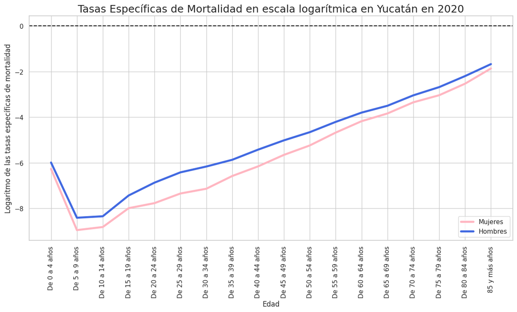

```python
sns.set_theme(style = 'whitegrid')
sns.lineplot(data = copia_tasa_esp_mort_2020, x ='Edad', y = 'TEM Mujeres', color = 'lightpink', linewidth = 3.5, label = 'Mujeres')
sns.lineplot(data = copia_tasa_esp_mort_2020, x ='Edad', y = 'TEM Hombres', color = 'royalblue', linewidth = 3.5, label = 'Hombres').axhline(0, ls='--', c='k')

plt.gcf().set_size_inches(15,7)
plt.title('Tasas Específicas de Mortalidad en escala logarítmica en Yucatán en 2020', fontsize = 18)
plt.ylabel('Logaritmo de las tasas específicas de mortalidad')
plt.xticks(rotation = 'vertical')
plt.show()
```

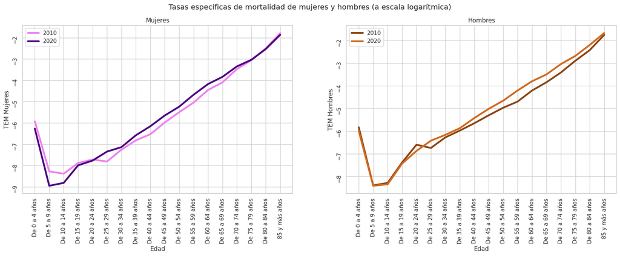

```python
fig, axes = plt.subplots(1,2,figsize = (21,6))
fig.suptitle('Tasas específicas de mortalidad de mujeres y hombres (a escala logarítmica)')

axes[0].set_title("Mujeres")
axes[1].set_title("Hombres")

sns.set_theme(style = "whitegrid")

# Se grafican las tasas para el primer subgráfico
sns.lineplot(ax = axes[0], data = copia_tasa_esp_mort_2010, x = 'Edad', y = 'TEM Mujeres', color = 'violet', linewidth = 3.5, label = '2010')
sns.lineplot(ax = axes[0], data = copia_tasa_esp_mort_2020, x = 'Edad', y = 'TEM Mujeres', color = 'indigo', linewidth = 3.5, label = '2020')

# Se grafican las tasas para el segundo subgráfico
sns.lineplot(ax = axes[1], data = copia_tasa_esp_mort_2010, x = 'Edad', y = 'TEM Hombres', color = 'saddlebrown', linewidth = 3.5, label = '2010')
sns.lineplot(ax = axes[1], data = copia_tasa_esp_mort_2020, x = 'Edad', y = 'TEM Hombres', color = 'chocolate', linewidth = 3.5, label = "2020")

axes[0].tick_params(labelrotation=90)
axes[1].tick_params(labelrotation=90)

plt.show()
```

# Tablas de mortalidad

```python
def_2010 = pd.read_excel('/content/defunciones 2010.xlsx')
def_2020 = pd.read_excel('/content/defunciones 2020.xlsx')

pob_2010 = pd.read_excel(r'/content/poblacion en 2010.xlsx')
pob_2020 = pd.read_excel(r'/content/poblacion en 2020.xlsx')
```

```python
def_2010 = def_2010.rename(columns = {'Hombre':'Hombres', 'Mujer':'Mujeres'})
def_2020 = def_2020.rename(columns = {'Hombre':'Hombres', 'Mujer':'Mujeres'})
```

```python
pob_2010 = pob_2010.rename(columns = {'Hombre':'Hombres', 'Mujer':'Mujeres'})
pob_2020 = pob_2020.rename(columns = {'Hombre':'Hombres', 'Mujer':'Mujeres'})
```

```python
pob_noesp_hombre = pob_2010['Hombres'][22]
pob_total_hombre = sum(pob_2010['Hombres'])

pob_noesp_mujer = pob_2010['Mujeres'][22]
pob_total_mujer = sum(pob_2010['Mujeres'])


fact_prorr_mujer = 1 + ((pob_noesp_mujer)/(pob_total_mujer - pob_noesp_mujer))
fact_prorr_hombre = 1 + ((pob_noesp_hombre)/(pob_total_hombre - pob_noesp_hombre))


pob_hombre_post_prorr = round(pob_2010['Hombres'][:22]*fact_prorr_hombre)
pob_mujer_post_prorr = round(pob_2010['Mujeres'][:22]*fact_prorr_mujer)

edad_actualizada = pob_2010['Edad'][:22]

# Creación del dataFrame
pob_2010_prorrted = pd.DataFrame({'Edad': edad_actualizada, 'Hombres': pob_hombre_post_prorr, 'Mujeres': pob_mujer_post_prorr})
```

```python
pob_noesp_hombre = pob_2020['Hombres'][21]
pob_total_hombre = sum(pob_2020['Hombres'])

pob_noesp_mujer = pob_2020['Mujeres'][21]
pob_total_mujer = sum(pob_2020['Mujeres'])


fact_prorr_mujer = 1 + ((pob_noesp_mujer)/(pob_total_mujer - pob_noesp_mujer))
fact_prorr_hombre = 1 + ((pob_noesp_hombre)/(pob_total_hombre - pob_noesp_hombre))


pob_hombre_post_prorr = round(pob_2020['Hombres'][:22]*fact_prorr_hombre)
pob_mujer_post_prorr = round(pob_2020['Mujeres'][:22]*fact_prorr_mujer)

edad_actualizada = pob_2020['Edad'][:22]

pob_2020_prorrted = pd.DataFrame({'Edad': edad_actualizada, 'Hombres': pob_hombre_post_prorr, 'Mujeres': pob_mujer_post_prorr})
```

```python
pob_2010_prorrted.iloc[0:1]
```

|  | Edad | Hombres | Mujeres |
| --- | --- | --- | --- |
| 0 | 0 Años | 16737.0 | 16130.0 |

```python
pob_2010_prorrted.iloc[1:5]
```

|  | Edad | Hombres | Mujeres |
| --- | --- | --- | --- |
| 1 | 1 Año | 16820.0 | 16434.0 |
| 2 | 2 Años | 17708.0 | 17268.0 |
| 3 | 3 Años | 17568.0 | 17683.0 |
| 4 | 4 Años | 17953.0 | 17532.0 |

```python
# HOMBRES
hombre_menor_a_1_anio_2010 = pob_2010_prorrted['Hombres'].values[0]
hombre_1_4_anios_2010 = sum(pob_2010_prorrted['Hombres'].values[1:5])

# MUJERES
mujer_menor_a_1_ano_2010 = pob_2010_prorrted['Mujeres'].values[0]
mujer_1_4_anios_2010 = sum(pob_2010_prorrted['Mujeres'].values[1:5])

pob_1_quinq_hombre_2010 = [hombre_menor_a_1_anio_2010, hombre_1_4_anios_2010]
pob_1_quinq_mujer_2010 = [mujer_menor_a_1_ano_2010, mujer_1_4_anios_2010]
```

```python
pob_2010_prorrted['Mujeres'].values[5:]
```

```
array([90268., 90256., 96024., 92899., 82436., 78812., 75688., 60820.,
       53011., 46399., 38308., 32129., 22967., 18563., 12567.,  8188.,
        7861.])
```

```python
nueva_pob_hombre_2010 = np.append(pob_1_quinq_hombre_2010, pob_2010_prorrted['Hombres'].values[5:] )
nueva_pob_mujer_2010 = np.append(pob_1_quinq_mujer_2010, pob_2010_prorrted['Mujeres'].values[5:] )
```

```python
pob_2010_prorrted_y_1_quinq = pd.DataFrame({"Edad":def_2010['Edad'],
                                         "Hombres":nueva_pob_hombre_2010,
                                         "Mujeres": nueva_pob_mujer_2010 })
```

```python
pob_2020_prorrted.iloc[0:1]
```

|  | Edad | Hombres | Mujeres |
| --- | --- | --- | --- |
| 0 | 0 Años | 16006.0 | 15626.0 |

```python
pob_2020_prorrted.iloc[1:5]
```

|  | Edad | Hombres | Mujeres |
| --- | --- | --- | --- |
| 1 | 1 Año | 17301.0 | 16935.0 |
| 2 | 2 Años | 18092.0 | 17364.0 |
| 3 | 3 Años | 18521.0 | 17920.0 |
| 4 | 4 Años | 19570.0 | 18952.0 |

```python
# HOMBRES
hombre_menor_a_1_anio_2020 = pob_2020_prorrted['Hombres'].values[0]
hombre_1_4_anios_2020 = sum(pob_2020_prorrted['Hombres'].values[1:5])

# MUJERES
mujer_menor_a_1_anio_2020 = pob_2020_prorrted['Mujeres'].values[0]
mujer_1_4_anios_2020 = sum(pob_2020_prorrted['Mujeres'].values[1:5])

pob_1_quinq_hombre_2020 = [hombre_menor_a_1_anio_2020, hombre_1_4_anios_2020]
pob_1_quinq_mujer_2020 = [mujer_menor_a_1_anio_2020, mujer_1_4_anios_2020]


pob_1_quinq_hombre_2020, pob_1_quinq_mujer_2020
```

```
([16006.0, 73484.0], [15626.0, 71171.0])
```

```python
pob_2020_prorrted['Hombres'].values[5:]
```

```
array([ 94064.,  95999.,  99589., 100258.,  94689.,  89357.,  85024.,
        77893.,  70368.,  57986.,  48910.,  34329.,  25422.,  17193.,
        10537.,   8288.,   1899.])
```

```python
pob_2020_prorrted['Mujeres'].values[5:]
```

```
array([92376., 93462., 97110., 99609., 96612., 93991., 89373., 83613.,
       75914., 64581., 54449., 38112., 27893., 18480., 11977., 10376.,
        1923.])
```

```python
nueva_pob_hombre_2020 = np.append(pob_1_quinq_hombre_2020, pob_2020_prorrted['Hombres'].values[5:] )
nueva_pob_mujer_2020 = np.append(pob_1_quinq_mujer_2020, pob_2020_prorrted['Mujeres'].values[5:] )
```

```python
pob_2020_prorrted_y_1_quinq = pd.DataFrame({"Edad":def_2020['Edad'],
                                         "Hombres":nueva_pob_hombre_2020,
                                         "Mujeres":nueva_pob_mujer_2020 })
```

```python
#metodo de 1/16
def metodo_1_16 (def_prorrted):
    pob_mujeres_1_16 = []
    pob_hombres_1_16 = []

    for i in range (3,16):

        if i == 3:
            formula_hombre = ( - sum(def_prorrted['Hombres'][0:2]) + (4 * def_prorrted['Hombres'][2]) + (10 * def_prorrted['Hombres'][3]) + (4 * def_prorrted['Hombres'][4]) - def_prorrted['Hombres'][5] ) / 16
            pob_hombres_1_16.append(formula_hombre)

            formula_mujer = ( - sum(def_prorrted['Mujeres'][0:2]) + (4 * def_prorrted['Mujeres'][2]) + (10 * def_prorrted['Mujeres'][3]) + (4 * def_prorrted['Mujeres'][4]) - def_prorrted['Mujeres'][5] ) / 16
            pob_mujeres_1_16.append(formula_mujer)

        else:
            formula_hombre = (- def_prorrted['Hombres'][i-2] + (4 * def_prorrted['Hombres'][i-1]) + (10 * def_prorrted['Hombres'][i]) + (4 * def_prorrted['Hombres'][i+1]) - def_prorrted['Hombres'][i+2])/16
            pob_hombres_1_16.append(formula_hombre)

            formula_mujer = (- def_prorrted['Mujeres'][i-2] + (4 * def_prorrted['Mujeres'][i-1]) + (10 * def_prorrted['Mujeres'][i]) + (4 * def_prorrted['Mujeres'][i+1]) - def_prorrted['Mujeres'][i+2])/16
            pob_mujeres_1_16.append(formula_mujer)

    pob_1_16 = def_prorrted.copy()
    pob_1_16.iloc[3:16, 1] = pob_hombres_1_16
    pob_1_16.iloc[3:16, 2] = pob_mujeres_1_16

    return pob_1_16.round()
```

```python
clear_pob_2010 = metodo_1_16(pob_2010_prorrted_y_1_quinq)
```

```python
clear_pob_2020 = metodo_1_16(pob_2020_prorrted_y_1_quinq)
```

```python
def tasa_crec(pob_inicial, pob_final):
    tasa_mujer = np.log(pob_inicial['Mujeres']/pob_final['Mujeres'])/10
    tasa_hombre = np.log(pob_inicial['Hombres']/pob_final['Hombres'])/10

    tasa_crec = pd.DataFrame({"Edad":pob_inicial['Edad'], "Tasa de Hombres": tasa_hombre, "Tasa de Mujeres": tasa_mujer})
    return tasa_crec
```

```python
tasas_2010_y_2020 = tasa_crec(clear_pob_2010, clear_pob_2020)
```

```python
pob_mitad_hombre_2010 = ((clear_pob_2010['Hombres'])*np.e**(tasas_2010_y_2020['Tasa de Hombres']*(19/365))).round()
pob_mitad_mujer_2010 = ((clear_pob_2010['Mujeres'])*np.e**(tasas_2010_y_2020['Tasa de Mujeres']*(19/365))).round()

pob_mitad_hombre_2020 = ((clear_pob_2020['Hombres'])*np.e**(tasas_2010_y_2020['Tasa de Hombres']*(108/365))).round()
pob_mitad_mujer_2020 = ((clear_pob_2020['Mujeres'])*np.e**(tasas_2010_y_2020['Tasa de Mujeres']*(108/365))).round()

cleared_pob_mitad_2010 = pd.DataFrame({'Edad':clear_pob_2010['Edad'], 'Hombres':pob_mitad_hombre_2010, 'Mujeres':pob_mitad_mujer_2010})
cleared_pob_mitad_2020 = pd.DataFrame({'Edad':clear_pob_2020['Edad'], 'Hombres':pob_mitad_hombre_2020, 'Mujeres':pob_mitad_mujer_2020})
```

```python
tasa_esp_mort_hombre_2020 = def_2020['Hombres']/cleared_pob_mitad_2020['Hombres']
tasa_esp_mort_mujer_2020 = def_2020['Mujeres']/cleared_pob_mitad_2020['Mujeres']

tasa_esp_mort_2020 = pd.DataFrame({'Edad':def_2020['Edad'], 'TEM Hombres':tasa_esp_mort_hombre_2020, 'TEM Mujeres':tasa_esp_mort_mujer_2020})
tasa_esp_mort_2020
```

|  | Edad | TEM Hombres | TEM Mujeres |
| --- | --- | --- | --- |
| 0 | Menores de 1 año | 0.012229 | 0.009015 |
| 1 | 1-4 años | 0.000395 | 0.000338 |
| 2 | 5-9 años | 0.000223 | 0.000130 |
| 3 | 10-14 años | 0.000238 | 0.000149 |
| 4 | 15-19 años | 0.000593 | 0.000340 |
| 5 | 20-24 años | 0.001047 | 0.000425 |
| 6 | 25-29 años | 0.001650 | 0.000651 |
| 7 | 30-34 años | 0.002132 | 0.000804 |
| 8 | 35-39 años | 0.002865 | 0.001405 |
| 9 | 40-44 años | 0.004496 | 0.002158 |
| 10 | 45-49 años | 0.006784 | 0.003587 |
| 11 | 50-54 años | 0.009631 | 0.005381 |
| 12 | 55-59 años | 0.015531 | 0.009749 |
| 13 | 60-64 años | 0.026551 | 0.018406 |
| 14 | 65-69 años | 0.041618 | 0.030201 |
| 15 | 70-74 años | 0.072412 | 0.053977 |
| 16 | 75-79 años | 0.112550 | 0.074871 |
| 17 | 80-84 años | 0.143255 | 0.093653 |
| 18 | 85 años y más | 0.793313 | 0.810973 |

```python
nax = np.array([0.1344, 0.38] + [0.5]*17)
n = np.array([1, 4] + [5]*17)

nmx_hombres_2020 = tasa_esp_mort_hombre_2020
```

```python
nqx_H_2020 = ((n)*(nmx_hombres_2020))/(1+((n)*(1-nax)*(nmx_hombres_2020)))
nqx_H_2020

nqx_H_2020[18] = 1
```

```python
nqx_H_2020 = ((n)*(nmx_hombres_2020))/(1+((n)*(1-nax)*(nmx_hombres_2020)))
nqx_H_2020

nqx_H_2020[18] = 1
```

```python
tabla_mort_hombre_2020 = pd.DataFrame()
tabla_mort_hombre_2020['x'] = tasa_esp_mort_2020['Edad']
tabla_mort_hombre_2020['nqx'] = nqx_H_2020
```

```python
tabla_mort_hombre_2020['lx'] = [100000] + [0]*18
tabla_mort_hombre_2020['ndx'] = [(tabla_mort_hombre_2020['lx'][0]) * (tabla_mort_hombre_2020['nqx'][0])] + [0]*18

tabla_mort_hombre_2020
```

|  | x | nqx | lx | ndx |
| --- | --- | --- | --- | --- |
| 0 | Menores de 1 año | 0.012101 | 100000 | 1210.126218 |
| 1 | 1-4 años | 0.001579 | 0 | 0.000000 |
| 2 | 5-9 años | 0.001116 | 0 | 0.000000 |
| 3 | 10-14 años | 0.001191 | 0 | 0.000000 |
| 4 | 15-19 años | 0.002963 | 0 | 0.000000 |
| 5 | 20-24 años | 0.005219 | 0 | 0.000000 |
| 6 | 25-29 años | 0.008214 | 0 | 0.000000 |
| 7 | 30-34 años | 0.010601 | 0 | 0.000000 |
| 8 | 35-39 años | 0.014224 | 0 | 0.000000 |
| 9 | 40-44 años | 0.022229 | 0 | 0.000000 |
| 10 | 45-49 años | 0.033352 | 0 | 0.000000 |
| 11 | 50-54 años | 0.047024 | 0 | 0.000000 |
| 12 | 55-59 años | 0.074753 | 0 | 0.000000 |
| 13 | 60-64 años | 0.124491 | 0 | 0.000000 |
| 14 | 65-69 años | 0.188481 | 0 | 0.000000 |
| 15 | 70-74 años | 0.306563 | 0 | 0.000000 |
| 16 | 75-79 años | 0.439175 | 0 | 0.000000 |
| 17 | 80-84 años | 0.527394 | 0 | 0.000000 |
| 18 | 85 años y más | 1.000000 | 0 | 0.000000 |

```python
for i in range(1, 19):
    tabla_mort_hombre_2020['lx'].values[i] = (tabla_mort_hombre_2020['lx'].values[i-1]) - (tabla_mort_hombre_2020['ndx'].values[i-1])
    tabla_mort_hombre_2020['ndx'].values[i] = (tabla_mort_hombre_2020['lx'].values[i]) * (tabla_mort_hombre_2020['nqx'].values[i])

tabla_mort_hombre_2020
```

|  | x | nqx | lx | ndx |
| --- | --- | --- | --- | --- |
| 0 | Menores de 1 año | 0.012101 | 100000 | 1210.126218 |
| 1 | 1-4 años | 0.001579 | 98789 | 156.013948 |
| 2 | 5-9 años | 0.001116 | 98632 | 110.092644 |
| 3 | 10-14 años | 0.001191 | 98521 | 117.339744 |
| 4 | 15-19 años | 0.002963 | 98403 | 291.564444 |
| 5 | 20-24 años | 0.005219 | 98111 | 512.051308 |
| 6 | 25-29 años | 0.008214 | 97598 | 801.676934 |
| 7 | 30-34 años | 0.010601 | 96796 | 1026.147992 |
| 8 | 35-39 años | 0.014224 | 95769 | 1362.241942 |
| 9 | 40-44 años | 0.022229 | 94406 | 2098.539136 |
| 10 | 45-49 años | 0.033352 | 92307 | 3078.635990 |
| 11 | 50-54 años | 0.047024 | 89228 | 4195.895928 |
| 12 | 55-59 años | 0.074753 | 85032 | 6356.399633 |
| 13 | 60-64 años | 0.124491 | 78675 | 9794.352525 |
| 14 | 65-69 años | 0.188481 | 68880 | 12982.552381 |
| 15 | 70-74 años | 0.306563 | 55897 | 17135.942259 |
| 16 | 75-79 años | 0.439175 | 38761 | 17022.881006 |
| 17 | 80-84 años | 0.527394 | 21738 | 11464.495323 |
| 18 | 85 años y más | 1.000000 | 10273 | 10273.000000 |

```python
tabla_mort_hombre_2020['nmx'] = nmx_hombres_2020
tabla_mort_hombre_2020
```

|  | x | nqx | lx | ndx | nmx |
| --- | --- | --- | --- | --- | --- |
| 0 | Menores de 1 año | 0.012101 | 100000 | 1210.126218 | 0.012229 |
| 1 | 1-4 años | 0.001579 | 98789 | 156.013948 | 0.000395 |
| 2 | 5-9 años | 0.001116 | 98632 | 110.092644 | 0.000223 |
| 3 | 10-14 años | 0.001191 | 98521 | 117.339744 | 0.000238 |
| 4 | 15-19 años | 0.002963 | 98403 | 291.564444 | 0.000593 |
| 5 | 20-24 años | 0.005219 | 98111 | 512.051308 | 0.001047 |
| 6 | 25-29 años | 0.008214 | 97598 | 801.676934 | 0.001650 |
| 7 | 30-34 años | 0.010601 | 96796 | 1026.147992 | 0.002132 |
| 8 | 35-39 años | 0.014224 | 95769 | 1362.241942 | 0.002865 |
| 9 | 40-44 años | 0.022229 | 94406 | 2098.539136 | 0.004496 |
| 10 | 45-49 años | 0.033352 | 92307 | 3078.635990 | 0.006784 |
| 11 | 50-54 años | 0.047024 | 89228 | 4195.895928 | 0.009631 |
| 12 | 55-59 años | 0.074753 | 85032 | 6356.399633 | 0.015531 |
| 13 | 60-64 años | 0.124491 | 78675 | 9794.352525 | 0.026551 |
| 14 | 65-69 años | 0.188481 | 68880 | 12982.552381 | 0.041618 |
| 15 | 70-74 años | 0.306563 | 55897 | 17135.942259 | 0.072412 |
| 16 | 75-79 años | 0.439175 | 38761 | 17022.881006 | 0.112550 |
| 17 | 80-84 años | 0.527394 | 21738 | 11464.495323 | 0.143255 |
| 18 | 85 años y más | 1.000000 | 10273 | 10273.000000 | 0.793313 |

```python
tabla_mort_hombre_2020['nLx'] = [0]*19

tabla_mort_hombre_2020['nLx'] = np.append(tabla_mort_hombre_2020['lx'][:-1],0)*n + tabla_mort_hombre_2020['ndx']*nax*n
tabla_mort_hombre_2020['nLx'].values[-1] = tabla_mort_hombre_2020['ndx'].values[-1] / tabla_mort_hombre_2020['nmx'].values[-1]
tabla_mort_hombre_2020
```

|  | x | nqx | lx | ndx | nmx | nLx |
| --- | --- | --- | --- | --- | --- | --- |
| 0 | Menores de 1 año | 0.012101 | 100000 | 1210.126218 | 0.012229 | 100162.640964 |
| 1 | 1-4 años | 0.001579 | 98789 | 156.013948 | 0.000395 | 395393.141200 |
| 2 | 5-9 años | 0.001116 | 98632 | 110.092644 | 0.000223 | 493435.231611 |
| 3 | 10-14 años | 0.001191 | 98521 | 117.339744 | 0.000238 | 492898.349360 |
| 4 | 15-19 años | 0.002963 | 98403 | 291.564444 | 0.000593 | 492743.911111 |
| 5 | 20-24 años | 0.005219 | 98111 | 512.051308 | 0.001047 | 491835.128269 |
| 6 | 25-29 años | 0.008214 | 97598 | 801.676934 | 0.001650 | 489994.192336 |
| 7 | 30-34 años | 0.010601 | 96796 | 1026.147992 | 0.002132 | 486545.369980 |
| 8 | 35-39 años | 0.014224 | 95769 | 1362.241942 | 0.002865 | 482250.604855 |
| 9 | 40-44 años | 0.022229 | 94406 | 2098.539136 | 0.004496 | 477276.347840 |
| 10 | 45-49 años | 0.033352 | 92307 | 3078.635990 | 0.006784 | 469231.589976 |
| 11 | 50-54 años | 0.047024 | 89228 | 4195.895928 | 0.009631 | 456629.739820 |
| 12 | 55-59 años | 0.074753 | 85032 | 6356.399633 | 0.015531 | 441050.999083 |
| 13 | 60-64 años | 0.124491 | 78675 | 9794.352525 | 0.026551 | 417860.881313 |
| 14 | 65-69 años | 0.188481 | 68880 | 12982.552381 | 0.041618 | 376856.380952 |
| 15 | 70-74 años | 0.306563 | 55897 | 17135.942259 | 0.072412 | 322324.855648 |
| 16 | 75-79 años | 0.439175 | 38761 | 17022.881006 | 0.112550 | 236362.202515 |
| 17 | 80-84 años | 0.527394 | 21738 | 11464.495323 | 0.143255 | 137351.238307 |
| 18 | 85 años y más | 1.000000 | 10273 | 10273.000000 | 0.793313 | 12949.490421 |

```python
tabla_mort_hombre_2020['Tx'] = [0]*19
for i in range(19):
    tabla_mort_hombre_2020['Tx'].values[i] = sum(tabla_mort_hombre_2020['nLx'][i:])
```

```python
tabla_mort_hombre_2020['ex'] = tabla_mort_hombre_2020['Tx']/tabla_mort_hombre_2020['lx']
tabla_mort_hombre_2020
```

|  | x | nqx | lx | ndx | nmx | nLx | Tx | ex |
| --- | --- | --- | --- | --- | --- | --- | --- | --- |
| 0 | Menores de 1 año | 0.012101 | 100000 | 1210.126218 | 0.012229 | 100162.640964 | 7273152 | 72.731520 |
| 1 | 1-4 años | 0.001579 | 98789 | 156.013948 | 0.000395 | 395393.141200 | 7172989 | 72.609187 |
| 2 | 5-9 años | 0.001116 | 98632 | 110.092644 | 0.000223 | 493435.231611 | 6777596 | 68.715995 |
| 3 | 10-14 años | 0.001191 | 98521 | 117.339744 | 0.000238 | 492898.349360 | 6284161 | 63.784990 |
| 4 | 15-19 años | 0.002963 | 98403 | 291.564444 | 0.000593 | 492743.911111 | 5791262 | 58.852494 |
| 5 | 20-24 años | 0.005219 | 98111 | 512.051308 | 0.001047 | 491835.128269 | 5298519 | 54.005351 |
| 6 | 25-29 años | 0.008214 | 97598 | 801.676934 | 0.001650 | 489994.192336 | 4806683 | 49.249810 |
| 7 | 30-34 años | 0.010601 | 96796 | 1026.147992 | 0.002132 | 486545.369980 | 4316689 | 44.595737 |
| 8 | 35-39 años | 0.014224 | 95769 | 1362.241942 | 0.002865 | 482250.604855 | 3830144 | 39.993568 |
| 9 | 40-44 años | 0.022229 | 94406 | 2098.539136 | 0.004496 | 477276.347840 | 3347893 | 35.462714 |
| 10 | 45-49 años | 0.033352 | 92307 | 3078.635990 | 0.006784 | 469231.589976 | 2870617 | 31.098584 |
| 11 | 50-54 años | 0.047024 | 89228 | 4195.895928 | 0.009631 | 456629.739820 | 2401385 | 26.912909 |
| 12 | 55-59 años | 0.074753 | 85032 | 6356.399633 | 0.015531 | 441050.999083 | 1944756 | 22.870872 |
| 13 | 60-64 años | 0.124491 | 78675 | 9794.352525 | 0.026551 | 417860.881313 | 1503705 | 19.112869 |
| 14 | 65-69 años | 0.188481 | 68880 | 12982.552381 | 0.041618 | 376856.380952 | 1085844 | 15.764286 |
| 15 | 70-74 años | 0.306563 | 55897 | 17135.942259 | 0.072412 | 322324.855648 | 708987 | 12.683811 |
| 16 | 75-79 años | 0.439175 | 38761 | 17022.881006 | 0.112550 | 236362.202515 | 386662 | 9.975542 |
| 17 | 80-84 años | 0.527394 | 21738 | 11464.495323 | 0.143255 | 137351.238307 | 150300 | 6.914160 |
| 18 | 85 años y más | 1.000000 | 10273 | 10273.000000 | 0.793313 | 12949.490421 | 12949 | 1.260489 |

```python
def tabla_mort(cleared_df_pob_mitad_anno, df_def, sexo):
    n = np.array([1, 4] + [5]*17)
    nax = np.array([0.1344, 0.38] + [0.5]*17)
    nmx = df_def[sexo]/cleared_df_pob_mitad_anno[sexo]

    tabla_mort = pd.DataFrame()

    tabla_mort['x'] = cleared_df_pob_mitad_anno['Edad']

    nqx = ((n)*(nmx))/(1+((n)*(1-nax)*(nmx)))
    nqx[18] = 1
    tabla_mort['nqx'] = nqx

    tabla_mort['lx'] = [100000] + [0]*18
    tabla_mort['ndx'] = [(tabla_mort['lx'][0]) * (tabla_mort['nqx'][0])] + [0]*18
    for i in range(1, 19):
        tabla_mort['lx'].values[i] = (tabla_mort['lx'].values[i-1]) - (tabla_mort['ndx'].values[i-1])
        tabla_mort['ndx'].values[i] = (tabla_mort['lx'].values[i]) * (tabla_mort['nqx'].values[i])

    tabla_mort['nmx'] = nmx

    tabla_mort['nLx'] = [0]*19
    tabla_mort['nLx'] = np.append(tabla_mort['lx'][:-1],0)*n + tabla_mort['ndx']*nax*n
    tabla_mort['nLx'].values[-1] = tabla_mort['ndx'].values[-1] / tabla_mort['nmx'].values[-1]

    tabla_mort['Tx'] = [0]*19
    for i in range(19):
        tabla_mort['Tx'].values[i] = sum(tabla_mort['nLx'][i:])

    tabla_mort['ex'] = tabla_mort['Tx']/tabla_mort['lx']

    return tabla_mort
```

```python
tabla_mort(cleared_pob_mitad_2010, def_2010, 'Hombres')
```

|  | x | nqx | lx | ndx | nmx | nLx | Tx | ex |
| --- | --- | --- | --- | --- | --- | --- | --- | --- |
| 0 | Menores de 1 año | 0.012877 | 100000 | 1287.677807 | 0.013022 | 100173.063897 | 7751539 | 77.515390 |
| 1 | 1-4 años | 0.002168 | 98712 | 213.960195 | 0.000543 | 395173.219497 | 7651366 | 77.512015 |
| 2 | 5-9 años | 0.001135 | 98498 | 111.759608 | 0.000227 | 492769.399020 | 7256193 | 73.668430 |
| 3 | 10-14 años | 0.001266 | 98386 | 124.545809 | 0.000253 | 492241.364523 | 6763423 | 68.743754 |
| 4 | 15-19 años | 0.003109 | 98261 | 305.525268 | 0.000623 | 492068.813171 | 6271182 | 63.821679 |
| 5 | 20-24 años | 0.006804 | 97955 | 666.440979 | 0.001365 | 491441.102448 | 5779113 | 58.997632 |
| 6 | 25-29 años | 0.005912 | 97288 | 575.206468 | 0.001186 | 487878.016169 | 5287672 | 54.350711 |
| 7 | 30-34 años | 0.009412 | 96712 | 910.267305 | 0.001891 | 485835.668262 | 4799794 | 49.629767 |
| 8 | 35-39 años | 0.012686 | 95801 | 1215.352133 | 0.002553 | 482043.380333 | 4313958 | 45.030407 |
| 9 | 40-44 años | 0.017462 | 94585 | 1651.687182 | 0.003523 | 477054.217956 | 3831915 | 40.512925 |
| 10 | 45-49 años | 0.024746 | 92933 | 2299.689304 | 0.005011 | 470414.223261 | 3354861 | 36.099782 |
| 11 | 50-54 años | 0.034335 | 90633 | 3111.908244 | 0.006987 | 460944.770610 | 2884446 | 31.825560 |
| 12 | 55-59 años | 0.044808 | 87521 | 3921.598863 | 0.009167 | 447408.997159 | 2423502 | 27.690520 |
| 13 | 60-64 años | 0.071928 | 83599 | 6013.123171 | 0.014922 | 433027.807927 | 1976093 | 23.637759 |
| 14 | 65-69 años | 0.101925 | 77585 | 7907.870895 | 0.021480 | 407694.677237 | 1543065 | 19.888703 |
| 15 | 70-74 años | 0.152522 | 69677 | 10627.279660 | 0.033023 | 374953.199150 | 1135370 | 16.294760 |
| 16 | 75-79 años | 0.243427 | 59049 | 14374.106472 | 0.055432 | 331180.266180 | 760417 | 12.877729 |
| 17 | 80-84 años | 0.363251 | 44674 | 16227.890536 | 0.088774 | 263939.726340 | 429237 | 9.608206 |
| 18 | 85 años y más | 1.000000 | 28446 | 28446.000000 | 0.172090 | 165297.457213 | 165297 | 5.810905 |

```python
tabla_mort(cleared_pob_mitad_2020, def_2020, 'Hombres')
```

|  | x | nqx | lx | ndx | nmx | nLx | Tx | ex |
| --- | --- | --- | --- | --- | --- | --- | --- | --- |
| 0 | Menores de 1 año | 0.012101 | 100000 | 1210.126218 | 0.012229 | 100162.640964 | 7273152 | 72.731520 |
| 1 | 1-4 años | 0.001579 | 98789 | 156.013948 | 0.000395 | 395393.141200 | 7172989 | 72.609187 |
| 2 | 5-9 años | 0.001116 | 98632 | 110.092644 | 0.000223 | 493435.231611 | 6777596 | 68.715995 |
| 3 | 10-14 años | 0.001191 | 98521 | 117.339744 | 0.000238 | 492898.349360 | 6284161 | 63.784990 |
| 4 | 15-19 años | 0.002963 | 98403 | 291.564444 | 0.000593 | 492743.911111 | 5791262 | 58.852494 |
| 5 | 20-24 años | 0.005219 | 98111 | 512.051308 | 0.001047 | 491835.128269 | 5298519 | 54.005351 |
| 6 | 25-29 años | 0.008214 | 97598 | 801.676934 | 0.001650 | 489994.192336 | 4806683 | 49.249810 |
| 7 | 30-34 años | 0.010601 | 96796 | 1026.147992 | 0.002132 | 486545.369980 | 4316689 | 44.595737 |
| 8 | 35-39 años | 0.014224 | 95769 | 1362.241942 | 0.002865 | 482250.604855 | 3830144 | 39.993568 |
| 9 | 40-44 años | 0.022229 | 94406 | 2098.539136 | 0.004496 | 477276.347840 | 3347893 | 35.462714 |
| 10 | 45-49 años | 0.033352 | 92307 | 3078.635990 | 0.006784 | 469231.589976 | 2870617 | 31.098584 |
| 11 | 50-54 años | 0.047024 | 89228 | 4195.895928 | 0.009631 | 456629.739820 | 2401385 | 26.912909 |
| 12 | 55-59 años | 0.074753 | 85032 | 6356.399633 | 0.015531 | 441050.999083 | 1944756 | 22.870872 |
| 13 | 60-64 años | 0.124491 | 78675 | 9794.352525 | 0.026551 | 417860.881313 | 1503705 | 19.112869 |
| 14 | 65-69 años | 0.188481 | 68880 | 12982.552381 | 0.041618 | 376856.380952 | 1085844 | 15.764286 |
| 15 | 70-74 años | 0.306563 | 55897 | 17135.942259 | 0.072412 | 322324.855648 | 708987 | 12.683811 |
| 16 | 75-79 años | 0.439175 | 38761 | 17022.881006 | 0.112550 | 236362.202515 | 386662 | 9.975542 |
| 17 | 80-84 años | 0.527394 | 21738 | 11464.495323 | 0.143255 | 137351.238307 | 150300 | 6.914160 |
| 18 | 85 años y más | 1.000000 | 10273 | 10273.000000 | 0.793313 | 12949.490421 | 12949 | 1.260489 |

```python
tabla_mort(cleared_pob_mitad_2010, def_2010, 'Mujeres')
```

|  | x | nqx | lx | ndx | nmx | nLx | Tx | ex |
| --- | --- | --- | --- | --- | --- | --- | --- | --- |
| 0 | Menores de 1 año | 0.012205 | 100000 | 1220.465472 | 0.012335 | 100164.030559 | 8065739 | 80.657390 |
| 1 | 1-4 años | 0.001682 | 98779 | 166.118812 | 0.000421 | 395368.500594 | 7965575 | 80.640369 |
| 2 | 5-9 años | 0.001273 | 98612 | 125.565441 | 0.000255 | 493373.913602 | 7570207 | 76.767604 |
| 3 | 10-14 años | 0.001143 | 98486 | 112.522973 | 0.000229 | 492711.307432 | 7076833 | 71.856233 |
| 4 | 15-19 años | 0.001893 | 98373 | 186.216492 | 0.000379 | 492330.541230 | 6584122 | 66.930174 |
| 5 | 20-24 años | 0.002224 | 98186 | 218.360355 | 0.000445 | 491475.900888 | 6091791 | 62.043377 |
| 6 | 25-29 años | 0.002030 | 97967 | 198.886885 | 0.000406 | 490332.217213 | 5600315 | 57.165321 |
| 7 | 30-34 años | 0.003533 | 97768 | 345.422014 | 0.000708 | 489703.555034 | 5109983 | 52.266416 |
| 8 | 35-39 años | 0.005482 | 97422 | 534.079308 | 0.001099 | 488445.198270 | 4620279 | 47.425417 |
| 9 | 40-44 años | 0.007281 | 96887 | 705.399435 | 0.001461 | 486198.498588 | 4131834 | 42.645907 |
| 10 | 45-49 años | 0.012630 | 96181 | 1214.749948 | 0.002542 | 483941.874870 | 3645636 | 37.903910 |
| 11 | 50-54 años | 0.020363 | 94966 | 1933.759333 | 0.004114 | 479664.398332 | 3161694 | 33.292905 |
| 12 | 55-59 años | 0.031861 | 93032 | 2964.118864 | 0.006475 | 472570.297160 | 2682030 | 28.829113 |
| 13 | 60-64 años | 0.056802 | 90067 | 5116.013595 | 0.011693 | 463125.033988 | 2209459 | 24.531282 |
| 14 | 65-69 años | 0.079965 | 84950 | 6792.988499 | 0.016659 | 441732.471247 | 1746334 | 20.557198 |
| 15 | 70-74 años | 0.144606 | 78157 | 11301.947012 | 0.031175 | 419039.867531 | 1304602 | 16.692069 |
| 16 | 75-79 años | 0.210994 | 66855 | 14106.036292 | 0.047176 | 369540.090731 | 885562 | 13.246010 |
| 17 | 80-84 años | 0.341681 | 52748 | 18022.990976 | 0.082416 | 308797.477441 | 516022 | 9.782778 |
| 18 | 85 años y más | 1.000000 | 34725 | 34725.000000 | 0.167572 | 207224.773926 | 207224 | 5.967574 |

```python
tabla_mort(cleared_pob_mitad_2020, def_2020, 'Mujeres')
```

|  | x | nqx | lx | ndx | nmx | nLx | Tx | ex |
| --- | --- | --- | --- | --- | --- | --- | --- | --- |
| 0 | Menores de 1 año | 0.008945 | 100000 | 894.496963 | 0.009015 | 100120.220392 | 7679015 | 76.790150 |
| 1 | 1-4 años | 0.001349 | 99105 | 133.695097 | 0.000338 | 396623.216547 | 7578895 | 76.473387 |
| 2 | 5-9 años | 0.000650 | 98971 | 64.306553 | 0.000130 | 495015.766382 | 7182271 | 72.569450 |
| 3 | 10-14 años | 0.000744 | 98906 | 73.573569 | 0.000149 | 494713.933923 | 6687256 | 67.612238 |
| 4 | 15-19 años | 0.001698 | 98832 | 167.824758 | 0.000340 | 494579.561895 | 6192542 | 62.657257 |
| 5 | 20-24 años | 0.002124 | 98664 | 209.573054 | 0.000425 | 493843.932635 | 5697962 | 57.751176 |
| 6 | 25-29 años | 0.003252 | 98454 | 320.188832 | 0.000651 | 493070.472080 | 5204118 | 52.858370 |
| 7 | 30-34 años | 0.004010 | 98133 | 393.549983 | 0.000804 | 491648.874957 | 4711048 | 48.006766 |
| 8 | 35-39 años | 0.007001 | 97739 | 684.228286 | 0.001405 | 490405.570714 | 4219399 | 43.170065 |
| 9 | 40-44 años | 0.010732 | 97054 | 1041.620410 | 0.002158 | 487874.051024 | 3728993 | 38.421837 |
| 10 | 45-49 años | 0.017776 | 96012 | 1706.721499 | 0.003587 | 484326.803746 | 3241119 | 33.757437 |
| 11 | 50-54 años | 0.026548 | 94305 | 2503.596167 | 0.005381 | 477783.990418 | 2756792 | 29.232724 |
| 12 | 55-59 años | 0.047586 | 91801 | 4368.481308 | 0.009749 | 469926.203270 | 2279008 | 24.825525 |
| 13 | 60-64 años | 0.087981 | 87432 | 7692.342352 | 0.018406 | 456390.855881 | 1809082 | 20.691303 |
| 14 | 65-69 años | 0.140404 | 79739 | 11195.676407 | 0.030201 | 426684.191018 | 1352691 | 16.963982 |
| 15 | 70-74 años | 0.237794 | 68543 | 16299.132063 | 0.053977 | 383462.830157 | 926007 | 13.509870 |
| 16 | 75-79 años | 0.315331 | 52243 | 16473.844371 | 0.074871 | 302399.610928 | 542544 | 10.385009 |
| 17 | 80-84 años | 0.379428 | 35769 | 13571.770928 | 0.093653 | 212774.427319 | 240145 | 6.713774 |
| 18 | 85 años y más | 1.000000 | 22197 | 22197.000000 | 0.810973 | 27370.839483 | 27370 | 1.233050 |

En hombres y mujeres disminuyeron las esperanzas de vida en todas las edades

# Tasas brutas de natalidad

```python
fecund_2010 = pd.read_excel(r'/content/fecundidad 2010 act.xlsx')
fecund_2020 = pd.read_excel(r'/content/fecundidad 2020 act.xlsx')


pob_mitad_ano_2010 = pd.read_excel('/content/mitadAnio_2010.xlsx')
pob_mitad_ano_2020 = pd.read_excel('/content/mitadAnio_2020.xlsx')
```

```python
# Para 2010
total_nacim_2010 = sum(fecund_2010['Nacimientos'])
total_pob_mitad_ano_2010 = sum(pob_mitad_ano_2010['Mujeres']+ pob_mitad_ano_2010['Hombres'])

tasa_bruta_nat_2010 = (total_nacim_2010/total_pob_mitad_ano_2010) * 1000


# Para 2020
total_nacim_2020 = sum(fecund_2020['Nacimientos'])
total_pob_mitad_ano_2020 = sum(pob_mitad_ano_2020['Mujeres']+ pob_mitad_ano_2020['Hombres'])

tasa_bruta_nat_2020 = (total_nacim_2020/total_pob_mitad_ano_2020) * 1000
```

```python
print(f'La Tasa Bruta de Natalidad en Yucatán de 2010 fue de {tasa_bruta_nat_2010}')
```

```
La Tasa Bruta de Natalidad en Yucatán de 2010 fue de 18.284592465330164
```

```python
print(f'La Tasa Bruta de Natalidad en Yucatán de 2020 fue de {tasa_bruta_nat_2020}')
```

```
La Tasa Bruta de Natalidad en Yucatán de 2020 fue de 12.689950786111108
```

Notemos que el número de nacimientos por cada 1000 habitantes disminuyó del 2010 al 2020.

# Tasas específicas de fecundidad

```python
def tasa_esp_fecund(df_fecundidad, df_pob_mitad_anno):

    num = df_fecundidad['Nacimientos'].values[1:8]
    denom = df_pob_mitad_anno['Mujeres'].values[3:10]
    tasa_esp_fecund = num/denom

    # Diseño del DataFrame
    df_tasa_esp_fecund = pd.DataFrame()
    df_tasa_esp_fecund['Edad'] = df_pob_mitad_anno['Edad'].values[3:10]
    df_tasa_esp_fecund['tasa_esp_fecund'] = tasa_esp_fecund

    return df_tasa_esp_fecund
```

```python
tasa_esp_fecund_2010 = tasa_esp_fecund(fecund_2010, pob_mitad_ano_2010)
tasa_esp_fecund_2010
```

|  | Edad | tasa_esp_fecund |
| --- | --- | --- |
| 0 | De 15 a 19 años | 0.064901 |
| 1 | De 20 a 24 años | 0.116828 |
| 2 | De 25 a 29 años | 0.112732 |
| 3 | De 30 a 34 años | 0.075747 |
| 4 | De 35 a 39 años | 0.036886 |
| 5 | De 40 a 44 años | 0.008198 |
| 6 | De 45 a 49 años | 0.000529 |

```python
tasa_esp_fecund_2020 = tasa_esp_fecund(fecund_2020, pob_mitad_ano_2020)
tasa_esp_fecund_2020
```

|  | Edad | tasa_esp_fecund |
| --- | --- | --- |
| 0 | De 15 a 19 años | 0.043114 |
| 1 | De 20 a 24 años | 0.082330 |
| 2 | De 25 a 29 años | 0.080759 |
| 3 | De 30 a 34 años | 0.059934 |
| 4 | De 35 a 39 años | 0.033151 |
| 5 | De 40 a 44 años | 0.007465 |
| 6 | De 45 a 49 años | 0.000341 |

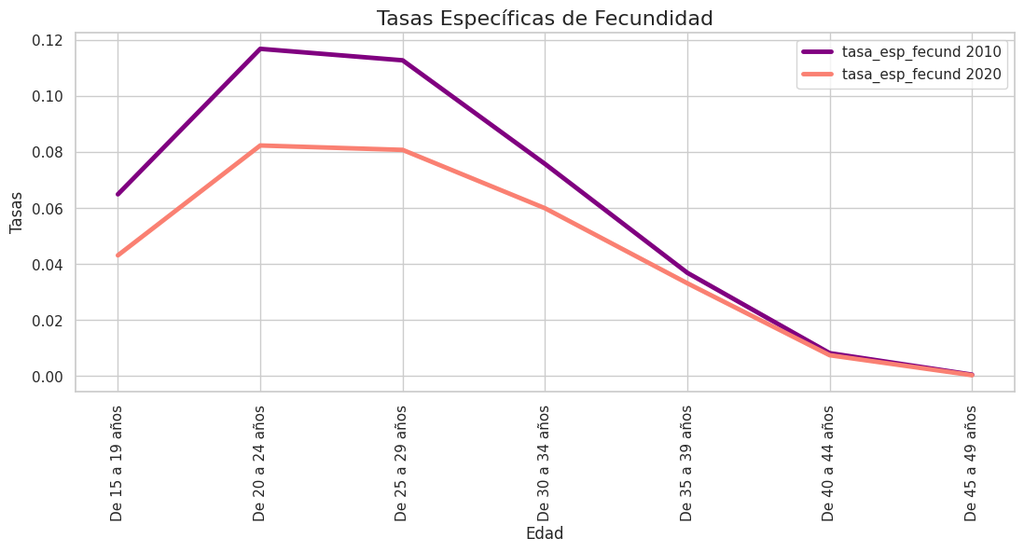

```python
sns.set_theme(style = "whitegrid")
sns.lineplot(data = tasa_esp_fecund_2010, x = 'Edad', y = 'tasa_esp_fecund', color = "purple", linewidth = 3.5, label = "tasa_esp_fecund 2010")
sns.lineplot(data = tasa_esp_fecund_2020, x = 'Edad', y = 'tasa_esp_fecund', color = "salmon", linewidth = 3.5, label = "tasa_esp_fecund 2020")

plt.title("Tasas Específicas de Fecundidad", fontsize = 16)
plt.ylabel("Tasas")
plt.gcf().set_size_inches(13, 5)
plt.xticks(rotation = 90)
plt.show()
```

# Tasa Global de Fecundidad y la Edad Media de la Fecundidad

```python
def tasa_global_fecund(tasa_esp_fecund):
    tasa_global_fecundidad = 5 * sum(tasa_esp_fecund['tasa_esp_fecund'])
    return tasa_global_fecundidad
```

```python
print(f'El número promedio de hijos de las mujeres fértiles en Yucatán en el 2010 fue de {tasa_global_fecund(tasa_esp_fecund_2010)}')
```

```
El número promedio de hijos de las mujeres fértiles en Yucatán en el 2010 fue de 2.079103464197411
```

```python
print(f'El número promedio de hijos de las mujeres fértiles en Yucatán en el 2020 fue de {tasa_global_fecund(tasa_esp_fecund_2020)}')
```

```
El número promedio de hijos de las mujeres fértiles en Yucatán en el 2020 fue de 1.5354666827783414
```

```python
fact_de_const = [5*i + 2.5 for i in range(3, 10)]
fact_de_const
```

```
[17.5, 22.5, 27.5, 32.5, 37.5, 42.5, 47.5]
```

```python
tasa_esp_fecund_2010_en_conj = tasa_esp_fecund_2010['tasa_esp_fecund'].values
tasa_esp_fecund_2020_en_conj = tasa_esp_fecund_2020['tasa_esp_fecund'].values

tasa_esp_fecund_2010_en_conj
```

```
array([0.06490144, 0.11682801, 0.1127317 , 0.07574668, 0.03688602,
       0.00819764, 0.0005292 ])
```

```python
# Para 2010
edad_media_fecund_2010 = sum((fact_de_const)*((5*tasa_esp_fecund_2010_en_conj)/tasa_global_fecund(tasa_esp_fecund_2010)))

# Para 2020
edad_media_fecund_2020 = sum((fact_de_const)*((5*tasa_esp_fecund_2020_en_conj)/tasa_global_fecund(tasa_esp_fecund_2020)))
```

```python
print(f'La edad media de fecundidad para las mujeres de Yucatán en el año 2010 fue de {edad_media_fecund_2010}')
```

```
La edad media de fecundidad para las mujeres de Yucatán en el año 2010 fue de 26.653451852799858
```

```python
print(f'La edad media de fecundidad para las mujeres de Yucatán en el añoo 2020 fue de {edad_media_fecund_2020}')
```

```
La edad media de fecundidad para las mujeres de Yucatán en el añoo 2020 fue de 27.197736066615036
```

Aquí es importante ver que, a pesar de ser un cambio mínimo, poco a poco la población femenina está dejando de tener hijos.

# Migración

```python
# Importamos el archivo
migra_2010 = pd.read_excel(r"/content/migracion2010.xlsx")
migra_2020 = pd.read_excel(r"/content/migracion2020.xlsx")
migra_2020
```

|  | Unnamed: 0 | Aguascalientes | Baja California | Baja California Sur | Campeche | Coahuila de Zaragoza | Colima | Chiapas | Chihuahua | Ciudad de México | ... | Sinaloa | Sonora | Tabasco | Tamaulipas | Tlaxcala | Veracruz de Ignacio de la Llave | Yucatán | Zacatecas | En los Estados Unidos de América | En otro país |
| --- | --- | --- | --- | --- | --- | --- | --- | --- | --- | --- | --- | --- | --- | --- | --- | --- | --- | --- | --- | --- | --- |
| 0 | Aguascalientes | NaN | 806.0 | 175.0 | 138.0 | 960.0 | 418.0 | 481.0 | 999.0 | 6426.0 | ... | 648.0 | 493.0 | 269.0 | 1083.0 | 225.0 | 1529.0 | 217.0 | 11244.0 | 6086 | 2607 |
| 1 | Baja California | 662.0 | NaN | 4916.0 | 346.0 | 952.0 | 2417.0 | 26171.0 | 2693.0 | 8196.0 | ... | 27621.0 | 16853.0 | 1968.0 | 1121.0 | 857.0 | 15404.0 | 351.0 | 1425.0 | 34576 | 8193 |
| 2 | Baja California Sur | 117.0 | 4354.0 | NaN | 204.0 | 449.0 | 447.0 | 3067.0 | 706.0 | 4376.0 | ... | 7073.0 | 2096.0 | 439.0 | 429.0 | 358.0 | 4773.0 | 172.0 | 214.0 | 2653 | 1319 |
| 3 | Campeche | 19.0 | 209.0 | 82.0 | NaN | 110.0 | 61.0 | 2317.0 | 232.0 | 1440.0 | ... | 180.0 | 151.0 | 6656.0 | 773.0 | 69.0 | 4499.0 | 2856.0 | 97.0 | 993 | 1226 |
| 4 | Coahuila de Zaragoza | 638.0 | 976.0 | 345.0 | 268.0 | NaN | 294.0 | 4617.0 | 6016.0 | 3528.0 | ... | 1076.0 | 1190.0 | 2138.0 | 4616.0 | 367.0 | 11157.0 | 247.0 | 3606.0 | 7646 | 3635 |
| 5 | Colima | 212.0 | 1288.0 | 193.0 | 100.0 | 172.0 | NaN | 1345.0 | 239.0 | 1854.0 | ... | 612.0 | 399.0 | 492.0 | 366.0 | 76.0 | 1184.0 | 73.0 | 255.0 | 3264 | 683 |
| 6 | Chiapas | 125.0 | 4531.0 | 513.0 | 1333.0 | 528.0 | 343.0 | NaN | 1015.0 | 5093.0 | ... | 884.0 | 1357.0 | 6961.0 | 1071.0 | 211.0 | 5036.0 | 810.0 | 253.0 | 5476 | 18459 |
| 7 | Chihuahua | 627.0 | 1887.0 | 393.0 | 372.0 | 6903.0 | 318.0 | 4514.0 | NaN | 4063.0 | ... | 3435.0 | 3803.0 | 1595.0 | 1046.0 | 172.0 | 20346.0 | 273.0 | 3019.0 | 17935 | 4644 |
| 8 | Ciudad de México | 1674.0 | 2999.0 | 1140.0 | 1264.0 | 1506.0 | 1033.0 | 5714.0 | 2451.0 | NaN | ... | 2561.0 | 2086.0 | 3253.0 | 2703.0 | 3001.0 | 19743.0 | 2186.0 | 923.0 | 11726 | 36865 |
| 9 | Durango | 410.0 | 1946.0 | 504.0 | 101.0 | 7520.0 | 195.0 | 311.0 | 7373.0 | 1657.0 | ... | 3183.0 | 930.0 | 201.0 | 858.0 | 56.0 | 832.0 | 107.0 | 2393.0 | 8491 | 893 |
| 10 | Guanajuato | 1705.0 | 2302.0 | 417.0 | 277.0 | 1699.0 | 772.0 | 2208.0 | 1501.0 | 15665.0 | ... | 1611.0 | 1267.0 | 1087.0 | 2835.0 | 805.0 | 6155.0 | 349.0 | 1673.0 | 25064 | 4691 |
| 11 | Guerrero | 168.0 | 2635.0 | 1760.0 | 162.0 | 290.0 | 784.0 | 821.0 | 704.0 | 8039.0 | ... | 3101.0 | 1117.0 | 357.0 | 478.0 | 218.0 | 1832.0 | 149.0 | 145.0 | 12623 | 644 |
| 12 | Hidalgo | 463.0 | 1299.0 | 329.0 | 284.0 | 726.0 | 312.0 | 1289.0 | 971.0 | 43545.0 | ... | 704.0 | 709.0 | 962.0 | 1830.0 | 1562.0 | 8545.0 | 412.0 | 443.0 | 11520 | 1761 |
| 13 | Jalisco | 4240.0 | 8482.0 | 2367.0 | 492.0 | 2177.0 | 10519.0 | 8566.0 | 2907.0 | 16478.0 | ... | 8887.0 | 4257.0 | 2183.0 | 2751.0 | 893.0 | 11373.0 | 906.0 | 6514.0 | 32520 | 10932 |
| 14 | México | 1413.0 | 3497.0 | 1230.0 | 901.0 | 1967.0 | 960.0 | 6557.0 | 2591.0 | 235494.0 | ... | 2270.0 | 2009.0 | 3005.0 | 3163.0 | 3731.0 | 25495.0 | 1567.0 | 1127.0 | 16607 | 11331 |
| 15 | Michoacán de Ocampo | 556.0 | 4421.0 | 552.0 | 336.0 | 584.0 | 2890.0 | 2456.0 | 780.0 | 10536.0 | ... | 1187.0 | 1242.0 | 783.0 | 1088.0 | 333.0 | 2724.0 | 300.0 | 440.0 | 27740 | 1820 |
| 16 | Morelos | 274.0 | 1148.0 | 297.0 | 167.0 | 391.0 | 165.0 | 1024.0 | 462.0 | 20843.0 | ... | 484.0 | 399.0 | 385.0 | 527.0 | 467.0 | 2462.0 | 281.0 | 274.0 | 6897 | 1792 |
| 17 | Nayarit | 414.0 | 4696.0 | 713.0 | 120.0 | 319.0 | 895.0 | 3300.0 | 504.0 | 2187.0 | ... | 3216.0 | 1388.0 | 250.0 | 317.0 | 107.0 | 1150.0 | 96.0 | 550.0 | 7007 | 995 |
| 18 | Nuevo León | 1112.0 | 2357.0 | 535.0 | 1315.0 | 16193.0 | 641.0 | 12859.0 | 4007.0 | 12056.0 | ... | 2739.0 | 2692.0 | 9747.0 | 40958.0 | 878.0 | 65554.0 | 998.0 | 4233.0 | 11911 | 14001 |
| 19 | Oaxaca | 163.0 | 4496.0 | 1194.0 | 640.0 | 621.0 | 402.0 | 6567.0 | 1594.0 | 14475.0 | ... | 1796.0 | 1777.0 | 1323.0 | 1094.0 | 386.0 | 13262.0 | 468.0 | 417.0 | 18142 | 1442 |
| 20 | Puebla | 480.0 | 2712.0 | 1199.0 | 917.0 | 984.0 | 302.0 | 4145.0 | 1327.0 | 26680.0 | ... | 893.0 | 1269.0 | 3173.0 | 2069.0 | 9072.0 | 30664.0 | 823.0 | 380.0 | 16124 | 5397 |
| 21 | Querétaro | 1227.0 | 1445.0 | 385.0 | 514.0 | 1611.0 | 581.0 | 3599.0 | 1495.0 | 41353.0 | ... | 1524.0 | 1181.0 | 2451.0 | 4626.0 | 1254.0 | 15814.0 | 626.0 | 738.0 | 7424 | 7658 |
| 22 | Quintana Roo | 407.0 | 992.0 | 626.0 | 9027.0 | 783.0 | 392.0 | 29436.0 | 1021.0 | 17700.0 | ... | 601.0 | 554.0 | 36743.0 | 1464.0 | 780.0 | 27679.0 | 15560.0 | 373.0 | 3837 | 12655 |
| 23 | San Luis Potosí | 1249.0 | 511.0 | 182.0 | 188.0 | 2271.0 | 275.0 | 812.0 | 881.0 | 5117.0 | ... | 676.0 | 615.0 | 593.0 | 9283.0 | 320.0 | 4515.0 | 144.0 | 2641.0 | 11664 | 2639 |
| 24 | Sinaloa | 284.0 | 12862.0 | 3597.0 | 216.0 | 848.0 | 622.0 | 1444.0 | 4521.0 | 3520.0 | ... | NaN | 10220.0 | 401.0 | 683.0 | 169.0 | 4647.0 | 192.0 | 899.0 | 7201 | 1589 |
| 25 | Sonora | 203.0 | 10431.0 | 1433.0 | 171.0 | 1100.0 | 395.0 | 4935.0 | 5021.0 | 3007.0 | ... | 17491.0 | NaN | 438.0 | 750.0 | 200.0 | 3688.0 | 242.0 | 495.0 | 13316 | 2030 |
| 26 | Tabasco | 74.0 | 321.0 | 96.0 | 4709.0 | 293.0 | 146.0 | 8406.0 | 327.0 | 1803.0 | ... | 232.0 | 255.0 | NaN | 1115.0 | 92.0 | 6690.0 | 1337.0 | 82.0 | 1161 | 2655 |
| 27 | Tamaulipas | 324.0 | 581.0 | 165.0 | 1142.0 | 2441.0 | 327.0 | 2675.0 | 859.0 | 3744.0 | ... | 566.0 | 580.0 | 3338.0 | NaN | 148.0 | 42478.0 | 309.0 | 487.0 | 14382 | 3720 |
| 28 | Tlaxcala | 132.0 | 566.0 | 125.0 | 91.0 | 234.0 | 55.0 | 639.0 | 235.0 | 6246.0 | ... | 170.0 | 259.0 | 385.0 | 337.0 | NaN | 2974.0 | 98.0 | 120.0 | 2281 | 546 |
| 29 | Veracruz de Ignacio de la Llave | 405.0 | 3678.0 | 1178.0 | 3539.0 | 1964.0 | 743.0 | 4895.0 | 4022.0 | 18631.0 | ... | 2160.0 | 1798.0 | 8016.0 | 17609.0 | 1317.0 | NaN | 1264.0 | 466.0 | 13335 | 3549 |
| 30 | Yucatán | 260.0 | 560.0 | 242.0 | 14616.0 | 497.0 | 139.0 | 4676.0 | 584.0 | 11890.0 | ... | 456.0 | 421.0 | 12135.0 | 946.0 | 174.0 | 8082.0 | NaN | 170.0 | 3458 | 4940 |
| 31 | Zacatecas | 3628.0 | 793.0 | 113.0 | 84.0 | 1887.0 | 245.0 | 279.0 | 2186.0 | 1539.0 | ... | 636.0 | 441.0 | 197.0 | 607.0 | 71.0 | 672.0 | 61.0 | NaN | 11095 | 619 |

32 rows × 35 columns

```python
# Reemplazamos los NA con ceros
migra_2020 = migra_2020.fillna(0)
```

```python
emigra_Yucat = migra_2020['Campeche'].sum()
emigra_Yucat
```

```
44034.0
```

```python
inmigra_yucat = migra_2020.loc[migra_2020['Unnamed: 0'] == 'Campeche'].drop('Unnamed: 0', axis = 1).sum(axis = 1).values[0]
```

```python
inmigra_yucat - emigra_Yucat
```

```
-13955.0
```

```python
def saldo_neto_migratorio(df_migra, periodo, entidad):
    df_migra = df_migra.fillna(0)
    emigra = df_migra[entidad].sum()
    inmigra = df_migra.loc[df_migra['Unnamed: 0'] == entidad].drop('Unnamed: 0', axis = 1).sum(axis = 1).values[0]
    snm = inmigra - emigra
    leyenda = print(f'El Saldo Neto Migratorio para la entidad de {entidad} en el anno {periodo} fue de {snm}')
    return leyenda
```

```python
migra_2020.columns
```

```
Index(['Unnamed: 0', 'Aguascalientes', 'Baja California',
       'Baja California Sur', 'Campeche', 'Coahuila de Zaragoza', 'Colima',
       'Chiapas', 'Chihuahua', 'Ciudad de México', 'Durango', 'Guanajuato',
       'Guerrero', 'Hidalgo', 'Jalisco', 'México', 'Michoacán de Ocampo',
       'Morelos', 'Nayarit', 'Nuevo León', 'Oaxaca', 'Puebla', 'Querétaro',
       'Quintana Roo', 'San Luis Potosí', 'Sinaloa', 'Sonora', 'Tabasco',
       'Tamaulipas', 'Tlaxcala', 'Veracruz de Ignacio de la Llave', 'Yucatán',
       'Zacatecas', 'En los Estados Unidos de América', 'En otro país'],
      dtype='object')
```

```python
saldo_neto_migratorio(migra_2010, 2010, 'Yucatán')
```

```
El Saldo Neto Migratorio para la entidad de Yucatán en el anno 2010 fue de 18833.0
```

```python
saldo_neto_migratorio(migra_2020, 2020, 'Yucatán')
```

```
El Saldo Neto Migratorio para la entidad de Yucatán en el anno 2020 fue de 75133.0
```

```python
migra_2010 = pd.read_excel(r"/content/migracion2010.xlsx")
migra_2020 = pd.read_excel(r"/content/migracion2020.xlsx")
```

```python
matrix = migra_2010.iloc[:, 1:-2].fillna(0)

# Y obtenemos el listado de todas las entidades federativas de México.
estados = migra_2010.iloc[:, 0]
```

```python
inmigra_hacia_la_entidad = matrix.loc[estados == 'Yucatán'].values.flatten()
inmigra_hacia_la_entidad
```

```
array([  158.,   454.,    90.,  6402.,   255.,    86.,  2506.,   330.,
        6419.,    95.,   464.,   326.,   291.,   854.,  1858.,   404.,
         404.,    34.,   668.,   768.,   957.,   239., 16931.,   207.,
         201.,   270.,  4452.,   443.,    80.,  3116.,     0.,    53.])
```

```python
emigra_desde_la_entidad = matrix['Yucatán'].values
emigra_desde_la_entidad
```

```
array([  109.,   342.,   146.,  3086.,   129.,    96.,   672.,   131.,
        1684.,    48.,   318.,   165.,   194.,   655.,  1285.,   231.,
         206.,    62.,   507.,   377.,   639.,   352., 23127.,   117.,
         145.,   187.,  1148.,   213.,    91.,  1443.,     0.,    27.])
```

```python
!pip install geopandas
import geopandas as gpd

mexico = gpd.read_file('https://raw.githubusercontent.com/angelnmara/geojson/master/mexicoHigh.json')
```

```python
mexico
```

|  | name | id | CNTRY | TYPE | geometry |
| --- | --- | --- | --- | --- | --- |
| 0 | Zacatecas | MX-ZAC | Mexico | State | POLYGON ((-100.8323 24.5549, -100.854 24.5395,... |
| 1 | Yucatán | MX-YUC | Mexico | State | POLYGON ((-87.5386 21.4864, -87.5309 21.4608, ... |
| 2 | Veracruz | MX-VER | Mexico | State | MULTIPOLYGON (((-97.4028 21.481, -97.426 21.43... |
| 3 | Tlaxcala | MX-TLA | Mexico | State | POLYGON ((-98.5849 19.4675, -98.6057 19.4902, ... |
| 4 | Tamaulipas | MX-TAM | Mexico | State | MULTIPOLYGON (((-97.7164 24.2767, -97.7135 24.... |
| 5 | Tabasco | MX-TAB | Mexico | State | MULTIPOLYGON (((-92.4681 18.6497, -92.4642 18.... |
| 6 | Sonora | MX-SON | Mexico | State | MULTIPOLYGON (((-112.2834 29.2332, -112.2815 2... |
| 7 | Sinaloa | MX-SIN | Mexico | State | MULTIPOLYGON (((-108.354 25.209, -108.3008 25.... |
| 8 | San Luis Potosí | MX-SLP | Mexico | State | POLYGON ((-100.1168 23.2482, -100.0878 23.2255... |
| 9 | Quintana Roo | MX-ROO | Mexico | State | MULTIPOLYGON (((-86.7275 20.5927, -86.7237 20.... |
| 10 | Querétaro | MX-QUE | Mexico | State | POLYGON ((-99.0424 21.2936, -99.0449 21.2723, ... |
| 11 | Puebla | MX-PUE | Mexico | State | POLYGON ((-96.6487 18.4294, -96.6811 18.3975, ... |
| 12 | Oaxaca | MX-OAX | Mexico | State | POLYGON ((-93.8739 17.1516, -93.8874 17.1154, ... |
| 13 | Nuevo León | MX-NLE | Mexico | State | POLYGON ((-99.7265 27.668, -99.7526 27.6559, -... |
| 14 | Nayarit | MX-NAY | Mexico | State | MULTIPOLYGON (((-105.6849 22.5718, -105.6733 2... |
| 15 | Morelos | MX-MOR | Mexico | State | POLYGON ((-98.8652 19.0714, -98.8261 19.04, -9... |
| 16 | Michoacán | MX-MIC | Mexico | State | POLYGON ((-100.3613 20.2965, -100.3241 20.283,... |
| 17 | México | MX-MEX | Mexico | State | POLYGON ((-98.6747 19.5501, -98.6661 19.525, -... |
| 18 | Jalisco | MX-JAL | Mexico | State | POLYGON ((-102.7748 21.6878, -102.7197 21.7231... |
| 19 | Hidalgo | MX-HID | Mexico | State | POLYGON ((-98.5362 21.411, -98.5023 21.4047, -... |
| 20 | Guerrero | MX-GRO | Mexico | State | POLYGON ((-99.4647 18.6613, -99.4443 18.6294, ... |
| 21 | Guanajuato | MX-GUA | Mexico | State | POLYGON ((-99.7816 21.5148, -99.7617 21.4965, ... |
| 22 | Durango | MX-DUR | Mexico | State | POLYGON ((-103.8685 26.7457, -103.8395 26.723,... |
| 23 | Ciudad de México | MX-CMX | Mexico | Federal District | POLYGON ((-98.8652 19.0714, -98.9033 19.0724, ... |
| 24 | Colima | MX-COL | Mexico | State | POLYGON ((-103.4926 18.9588, -103.5429 18.9076... |
| 25 | Coahuila | MX-COA | Mexico | State | POLYGON ((-99.8434 27.7651, -99.8535 27.7434, ... |
| 26 | Chihuahua | MX-CHH | Mexico | State | POLYGON ((-103.3854 29.0245, -103.4038 29.0018... |
| 27 | Chiapas | MX-CHP | Mexico | State | MULTIPOLYGON (((-94.1082 16.0535, -94.1009 16.... |
| 28 | Campeche | MX-CAM | Mexico | State | MULTIPOLYGON (((-91.5308 18.7791, -91.5111 18.... |
| 29 | Baja California Sur | MX-BCS | Mexico | State | MULTIPOLYGON (((-114.7394 18.3743, -114.725 18... |
| 30 | Baja California | MX-BCN | Mexico | State | MULTIPOLYGON (((-112.8931 28.6791, -112.8602 2... |
| 31 | Aguascalientes | MX-AGU | Mexico | State | POLYGON ((-102.7748 21.6878, -102.7883 21.6917... |

```python
state_names = migra_2010.iloc[:,0].replace({
    'Coahuila de Zaragoza' : 'Coahuila',
    'Distrito Federal' : 'Ciudad de México',
    'Michoacán de Ocampo' : 'Michoacán',
    'Veracruz de Ignacio de la Llave' : 'Veracruz'
})
```

```python
emigra_dicc = dict(zip(state_names, emigra_desde_la_entidad))
inmigra_dicc = dict(zip(state_names, inmigra_hacia_la_entidad))
```

```python
mexico['inmigra estatal'] = mexico['name'].map(inmigra_dicc)
mexico['emigra estatal'] = mexico['name'].map(emigra_dicc)
```

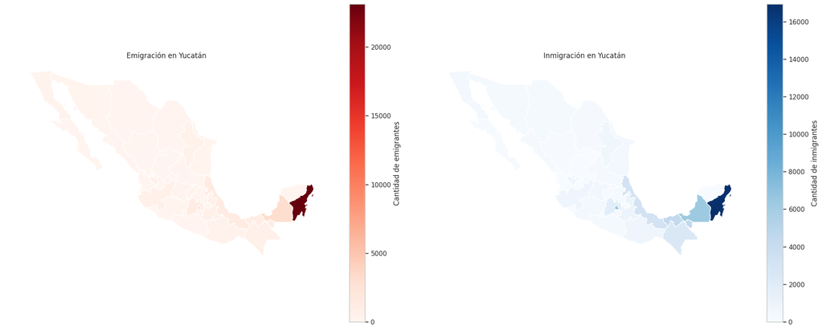

```python
# Grafica

fig, (ax1, ax2) = plt.subplots(1, 2, figsize = (20, 8))
mexico.plot(column = 'emigra estatal', ax=ax1, legend = True, cmap = 'Reds', legend_kwds = {'label' : f'Cantidad de emigrantes'})
ax1.set_title(f'Emigración en Yucatán')
ax1.axis('off')

mexico.plot(column = 'inmigra estatal', ax=ax2, legend = True, cmap = 'Blues', legend_kwds = {'label' : f'Cantidad de inmigrantes'})
ax2.set_title(f'Inmigración en Yucatán')
ax2.axis('off')

plt.tight_layout()
plt.show()
```

```python
def mapas_calor_2010(df_migra, entidad):
    matrix = df_migra.iloc[:, 1:-2].fillna(0)
    estados = df_migra.iloc[:, 0]
    inmigra_hacia_la_entidad = matrix.loc[estados == entidad].values.flatten()
    emigra_desde_la_entidad = matrix[entidad].values
    mexico = gpd.read_file('https://raw.githubusercontent.com/angelnmara/geojson/master/mexicoHigh.json')
    state_names = df_migra.iloc[:,0].replace({
    'Coahuila de Zaragoza' : 'Coahuila',
    'Distrito Federal' : 'Ciudad de México',
    'Michoacán de Ocampo' : 'Michoacán',
    'Veracruz de Ignacio de la Llave' : 'Veracruz'})
    emigra_dicc = dict(zip(state_names, emigra_desde_la_entidad))
    inmigra_dicc = dict(zip(state_names, inmigra_hacia_la_entidad))
    mexico['inmigra estatal'] = mexico['name'].map(inmigra_dicc)
    mexico['emigra estatal'] = mexico['name'].map(emigra_dicc)
    # Graficamos
    fig, (ax1, ax2) = plt.subplots(1, 2, figsize = (20, 8))
    mexico.plot(column = 'emigra estatal', ax=ax1, legend = True, cmap = 'Reds', legend_kwds = {'label' : f'Cantidad de emigrantes'})
    ax1.set_title(f'Emigración en Yucatán en 2010')
    ax1.axis('off')

    mexico.plot(column = 'inmigra estatal', ax=ax2, legend = True, cmap = 'Blues', legend_kwds = {'label' : f'Cantidad de inmigrantes'})
    ax2.set_title(f'Inmigración en Yucatán en 2010')
    ax2.axis('off')

    plt.tight_layout()
    plt.show()
```

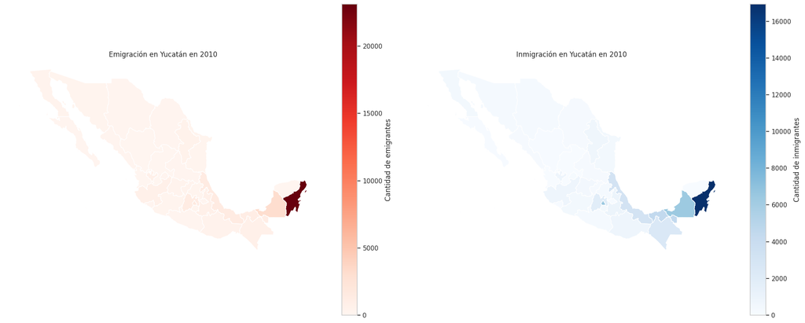

```python
mapas_calor_2010(migra_2010, 'Yucatán')
```

```python
def mapas_calor_2020(df_migra, entidad):
    matrix = df_migra.iloc[:, 1:-2].fillna(0)
    estados = df_migra.iloc[:, 0]
    inmigra_hacia_la_entidad = matrix.loc[estados == entidad].values.flatten()
    emigra_desde_la_entidad = matrix[entidad].values
    mexico = gpd.read_file('https://raw.githubusercontent.com/angelnmara/geojson/master/mexicoHigh.json')
    state_names = df_migra.iloc[:,0].replace({
    'Coahuila de Zaragoza' : 'Coahuila',
    'Michoacán de Ocampo' : 'Michoacán',
    'Veracruz de Ignacio de la Llave' : 'Veracruz'})
    emigra_dicc = dict(zip(state_names, emigra_desde_la_entidad))
    inmigra_dicc = dict(zip(state_names, inmigra_hacia_la_entidad))
    mexico['inmigra estatal'] = mexico['name'].map(inmigra_dicc)
    mexico['emigra estatal'] = mexico['name'].map(emigra_dicc)
    # Graficamos
    fig, (ax1, ax2) = plt.subplots(1, 2, figsize = (20, 8))
    mexico.plot(column = 'emigra estatal', ax=ax1, legend = True, cmap = 'Reds', legend_kwds = {'label' : f'Cantidad de emigrantes'})
    ax1.set_title(f'Emigración en Yucatán en 2020')
    ax1.axis('off')

    mexico.plot(column = 'inmigra estatal', ax=ax2, legend = True, cmap = 'Blues', legend_kwds = {'label' : f'Cantidad de inmigrantes'})
    ax2.set_title(f'Inmigración en Yucatán en 2020')
    ax2.axis('off')

    plt.tight_layout()
    plt.show()
```

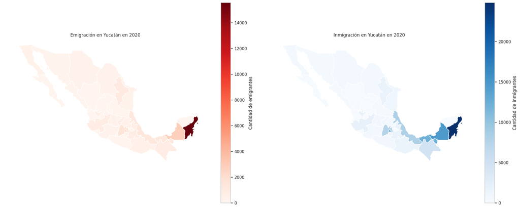

```python
mapas_calor_2020(migra_2020, 'Yucatán')
```

Del año 2010 al 2020 se disminuyó la cantidad de emigrantes, mientras que la cantidad de inmigrantes aumentó de la década del 2010 a la de 2020.

# Proyecciones

```python
pob_mitad_anno = pd.read_csv(r'/content/00_Pob_Mitad_1950_2070.csv')

defs = pd.read_csv(r'/content/01_Defunciones_1950_2070.csv')
```

```python
estados = defs.iloc[: , 2]
annos = defs.iloc[:, 1]
```

```python
defs.loc[estados == 'Yucatán']
```

|  | RENGLON | AÑO | ENTIDAD | CVE_GEO | SEXO | EDAD | DEFUNCIONES |
| --- | --- | --- | --- | --- | --- | --- | --- |
| 11220 | 11221 | 1970 | Yucatán | 31 | Hombres | 0 | 1786 |
| 11221 | 11222 | 1970 | Yucatán | 31 | Mujeres | 0 | 1449 |
| 11222 | 11223 | 1970 | Yucatán | 31 | Hombres | 1 | 527 |
| 11223 | 11224 | 1970 | Yucatán | 31 | Mujeres | 1 | 476 |
| 11224 | 11225 | 1970 | Yucatán | 31 | Hombres | 2 | 221 |
| ... | ... | ... | ... | ... | ... | ... | ... |
| 737435 | 737436 | 2070 | Yucatán | 31 | Mujeres | 107 | 48 |
| 737436 | 737437 | 2070 | Yucatán | 31 | Hombres | 108 | 46 |
| 737437 | 737438 | 2070 | Yucatán | 31 | Mujeres | 108 | 32 |
| 737438 | 737439 | 2070 | Yucatán | 31 | Hombres | 109 | 35 |
| 737439 | 737440 | 2070 | Yucatán | 31 | Mujeres | 109 | 21 |

22220 rows × 7 columns

```python
defs.loc[annos == 2070]
```

|  | RENGLON | AÑO | ENTIDAD | CVE_GEO | SEXO | EDAD | DEFUNCIONES |
| --- | --- | --- | --- | --- | --- | --- | --- |
| 730400 | 730401 | 2070 | República Mexicana | 0 | Hombres | 0 | 1389 |
| 730401 | 730402 | 2070 | República Mexicana | 0 | Mujeres | 0 | 1062 |
| 730402 | 730403 | 2070 | República Mexicana | 0 | Hombres | 1 | 88 |
| 730403 | 730404 | 2070 | República Mexicana | 0 | Mujeres | 1 | 76 |
| 730404 | 730405 | 2070 | República Mexicana | 0 | Hombres | 2 | 17 |
| ... | ... | ... | ... | ... | ... | ... | ... |
| 737655 | 737656 | 2070 | Zacatecas | 32 | Mujeres | 107 | 23 |
| 737656 | 737657 | 2070 | Zacatecas | 32 | Hombres | 108 | 25 |
| 737657 | 737658 | 2070 | Zacatecas | 32 | Mujeres | 108 | 15 |
| 737658 | 737659 | 2070 | Zacatecas | 32 | Hombres | 109 | 19 |
| 737659 | 737660 | 2070 | Zacatecas | 32 | Mujeres | 109 | 10 |

7260 rows × 7 columns

```python
filtrar_por_anno = defs.loc[annos == 2070]
```

```python
filtrar_por_anno_y_entidad = filtrar_por_anno.loc[estados == 'Yucatán']
```

```python
filtrar_por_anno_y_entidad
```

|  | RENGLON | AÑO | ENTIDAD | CVE_GEO | SEXO | EDAD | DEFUNCIONES |
| --- | --- | --- | --- | --- | --- | --- | --- |
| 737220 | 737221 | 2070 | Yucatán | 31 | Hombres | 0 | 23 |
| 737221 | 737222 | 2070 | Yucatán | 31 | Mujeres | 0 | 18 |
| 737222 | 737223 | 2070 | Yucatán | 31 | Hombres | 1 | 1 |
| 737223 | 737224 | 2070 | Yucatán | 31 | Mujeres | 1 | 1 |
| 737224 | 737225 | 2070 | Yucatán | 31 | Hombres | 2 | 0 |
| ... | ... | ... | ... | ... | ... | ... | ... |
| 737435 | 737436 | 2070 | Yucatán | 31 | Mujeres | 107 | 48 |
| 737436 | 737437 | 2070 | Yucatán | 31 | Hombres | 108 | 46 |
| 737437 | 737438 | 2070 | Yucatán | 31 | Mujeres | 108 | 32 |
| 737438 | 737439 | 2070 | Yucatán | 31 | Hombres | 109 | 35 |
| 737439 | 737440 | 2070 | Yucatán | 31 | Mujeres | 109 | 21 |

220 rows × 7 columns

```python
def_casi_limpio = filtrar_por_anno_y_entidad.drop(['RENGLON', 'AÑO', 'ENTIDAD', 'CVE_GEO'], axis = 1)
```

```python
sexo = def_casi_limpio.iloc[:, 0]
sexo
```

|  | SEXO |
| --- | --- |
| 737220 | Hombres |
| 737221 | Mujeres |
| 737222 | Hombres |
| 737223 | Mujeres |
| 737224 | Hombres |
| ... | ... |
| 737435 | Mujeres |
| 737436 | Hombres |
| 737437 | Mujeres |
| 737438 | Hombres |
| 737439 | Mujeres |

220 rows × 1 columns

**dtype:** object

```python
mujeres_DEF = def_casi_limpio.loc[sexo == 'Mujeres']
```

```python
mujeres_DEF = mujeres_DEF.drop(['SEXO'], axis = 1)
```

```python
hombres_DEF = def_casi_limpio.loc[sexo == 'Hombres']
```

```python
hombres_DEF = hombres_DEF.drop(['SEXO'], axis = 1)
```

```python
mujeres_DEF = mujeres_DEF.rename({'defs' : 'Mujeres'}, axis = 1)
hombres_DEF = hombres_DEF.rename({'defs' : 'Hombres'}, axis = 1)
```

```python
defs_2070 = (pd.merge(hombres_DEF, mujeres_DEF, on = 'EDAD')).rename({'EDAD':'Edad'}, axis = 1)
```

```python
def df_limpio(df, entidad, año):
    estados = df.iloc[:, 2] # Pues la columna asociada al índice 2 es la entidad
    años = df.iloc[:, 1] # Pues la entidad donde filtraremos los años es la del índice 1
    filtra_año = df.loc[años == año]
    filtra_año_y_entidad = filtra_año.loc[estados == entidad]

    # Elimina columnas que no ocupamos
    df_filtrar_por_sexo = filtra_año_y_entidad.drop(['RENGLON', 'AÑO', 'ENTIDAD', 'CVE_GEO'], axis = 1)
    sexo = df_filtrar_por_sexo['SEXO']

    if 'DEFUNCIONES' in df_filtrar_por_sexo:
        mujeres = (df_filtrar_por_sexo.loc[sexo == 'Mujeres']).drop(['SEXO'], axis = 1)
        mujeres = mujeres.rename({'DEFUNCIONES' : 'Mujeres'}, axis = 1)

        hombres = (df_filtrar_por_sexo.loc[sexo == 'Hombres']).drop(['SEXO'], axis = 1)
        hombres = hombres.rename({'DEFUNCIONES' : 'Hombres'}, axis = 1)

        union_df = pd.merge(hombres, mujeres, on = 'EDAD')
        union_df = union_df.rename({'EDAD': 'Edad'}, axis = 1)

    elif 'POBLACION' in df_filtrar_por_sexo:
        mujeres = (df_filtrar_por_sexo.loc[sexo == 'Mujeres']).drop(['SEXO'], axis = 1)
        mujeres = mujeres.rename({'POBLACION' : 'Mujeres'}, axis = 1)

        hombres = (df_filtrar_por_sexo.loc[sexo == 'Hombres']).drop(['SEXO'], axis = 1)
        hombres = hombres.rename({'POBLACION' : 'Hombres'}, axis = 1)

        union_df = pd.merge(hombres, mujeres, on = 'EDAD')
        union_df = union_df.rename({'EDAD': 'Edad'}, axis = 1)

    return union_df
```

```python
pob_mitad_anno_2070 = df_limpio(pob_mitad_anno, 'Yucatán', 2070)
pob_mitad_anno_2070
```

|  | Edad | Hombres | Mujeres |
| --- | --- | --- | --- |
| 0 | 0 | 9644 | 9267 |
| 1 | 1 | 9787 | 9393 |
| 2 | 2 | 9934 | 9525 |
| 3 | 3 | 10085 | 9662 |
| 4 | 4 | 10239 | 9803 |
| ... | ... | ... | ... |
| 105 | 105 | 375 | 235 |
| 106 | 106 | 274 | 153 |
| 107 | 107 | 196 | 96 |
| 108 | 108 | 137 | 58 |
| 109 | 109 | 93 | 33 |

110 rows × 3 columns

```python
def_2070 = df_limpio(defs, 'Yucatán', 2070)
def_2070
```

|  | Edad | Hombres | Mujeres |
| --- | --- | --- | --- |
| 0 | 0 | 23 | 18 |
| 1 | 1 | 1 | 1 |
| 2 | 2 | 0 | 0 |
| 3 | 3 | 0 | 0 |
| 4 | 4 | 0 | 0 |
| ... | ... | ... | ... |
| 105 | 105 | 99 | 94 |
| 106 | 106 | 79 | 68 |
| 107 | 107 | 61 | 48 |
| 108 | 108 | 46 | 32 |
| 109 | 109 | 35 | 21 |

110 rows × 3 columns

```python
TEM_hombre = def_2070['Hombres'] / pob_mitad_anno_2070['Hombres']
TEM_mujer = def_2070['Mujeres'] / pob_mitad_anno_2070['Mujeres']
```

```python
TEM = pd.DataFrame({
    'Edad' : pob_mitad_anno_2070['Edad'],
    'TEM Hombres' : TEM_hombre,})
```

```python
nax = np.array([0.1344] + [0.3875]*4 + [0.5]*105)
n = np.array([1]*110)

nmx_H = TEM_hombre
```

```python
nqx_H = ((n)*(nmx_H))/(1 + ((n)*(1-nax)*(nmx_H)))
nqx_H
```

|  | Hombres |
| --- | --- |
| 0 | 0.002380 |
| 1 | 0.000102 |
| 2 | 0.000000 |
| 3 | 0.000000 |
| 4 | 0.000000 |
| ... | ... |
| 105 | 0.233216 |
| 106 | 0.251994 |
| 107 | 0.269316 |
| 108 | 0.287500 |
| 109 | 0.316742 |

110 rows × 1 columns

**dtype:** float64

```python
nqx_H.iloc[-1] = 1
nqx_H
```

|  | Hombres |
| --- | --- |
| 0 | 0.002380 |
| 1 | 0.000102 |
| 2 | 0.000000 |
| 3 | 0.000000 |
| 4 | 0.000000 |
| ... | ... |
| 105 | 0.233216 |
| 106 | 0.251994 |
| 107 | 0.269316 |
| 108 | 0.287500 |
| 109 | 1.000000 |

110 rows × 1 columns

**dtype:** float64

```python
tabla_mort_completa_hombre = pd.DataFrame()

tabla_mort_completa_hombre['x'] = TEM['Edad']
```

```python
tabla_mort_completa_hombre['nqx'] = nqx_H

tabla_mort_completa_hombre
```

|  | x | nqx |
| --- | --- | --- |
| 0 | 0 | 0.002380 |
| 1 | 1 | 0.000102 |
| 2 | 2 | 0.000000 |
| 3 | 3 | 0.000000 |
| 4 | 4 | 0.000000 |
| ... | ... | ... |
| 105 | 105 | 0.233216 |
| 106 | 106 | 0.251994 |
| 107 | 107 | 0.269316 |
| 108 | 108 | 0.287500 |
| 109 | 109 | 1.000000 |

110 rows × 2 columns

```python
tabla_mort_completa_hombre['lx'] = [100000] + [0]*109
tabla_mort_completa_hombre['dx'] = [( tabla_mort_completa_hombre['lx'][0] ) * (tabla_mort_completa_hombre['nqx'][0]) ] + [0]*109
```

```python
tabla_mort_completa_hombre
```

|  | x | nqx | lx | dx |
| --- | --- | --- | --- | --- |
| 0 | 0 | 0.002380 | 100000 | 237.998935 |
| 1 | 1 | 0.000102 | 0 | 0.000000 |
| 2 | 2 | 0.000000 | 0 | 0.000000 |
| 3 | 3 | 0.000000 | 0 | 0.000000 |
| 4 | 4 | 0.000000 | 0 | 0.000000 |
| ... | ... | ... | ... | ... |
| 105 | 105 | 0.233216 | 0 | 0.000000 |
| 106 | 106 | 0.251994 | 0 | 0.000000 |
| 107 | 107 | 0.269316 | 0 | 0.000000 |
| 108 | 108 | 0.287500 | 0 | 0.000000 |
| 109 | 109 | 1.000000 | 0 | 0.000000 |

110 rows × 4 columns

```python
for i in range(1, 110):
    tabla_mort_completa_hombre['lx'].values[i] = (tabla_mort_completa_hombre['lx'].values[i-1]) - (tabla_mort_completa_hombre['dx'].values[i-1])
    tabla_mort_completa_hombre['dx'].values[i] = (tabla_mort_completa_hombre['lx'].values[i]) * (tabla_mort_completa_hombre['nqx'].values[i])

tabla_mort_completa_hombre
```

|  | x | nqx | lx | dx |
| --- | --- | --- | --- | --- |
| 0 | 0 | 0.002380 | 100000 | 237.998935 |
| 1 | 1 | 0.000102 | 99762 | 10.192680 |
| 2 | 2 | 0.000000 | 99751 | 0.000000 |
| 3 | 3 | 0.000000 | 99751 | 0.000000 |
| 4 | 4 | 0.000000 | 99751 | 0.000000 |
| ... | ... | ... | ... | ... |
| 105 | 105 | 0.233216 | 4179 | 974.607774 |
| 106 | 106 | 0.251994 | 3204 | 807.387560 |
| 107 | 107 | 0.269316 | 2396 | 645.280353 |
| 108 | 108 | 0.287500 | 1750 | 503.125000 |
| 109 | 109 | 1.000000 | 1246 | 1246.000000 |

110 rows × 4 columns

```python
tabla_mort_completa_hombre['nmx'] = nmx_H
tabla_mort_completa_hombre
```

|  | x | nqx | lx | dx | nmx |
| --- | --- | --- | --- | --- | --- |
| 0 | 0 | 0.002380 | 100000 | 237.998935 | 0.002385 |
| 1 | 1 | 0.000102 | 99762 | 10.192680 | 0.000102 |
| 2 | 2 | 0.000000 | 99751 | 0.000000 | 0.000000 |
| 3 | 3 | 0.000000 | 99751 | 0.000000 | 0.000000 |
| 4 | 4 | 0.000000 | 99751 | 0.000000 | 0.000000 |
| ... | ... | ... | ... | ... | ... |
| 105 | 105 | 0.233216 | 4179 | 974.607774 | 0.264000 |
| 106 | 106 | 0.251994 | 3204 | 807.387560 | 0.288321 |
| 107 | 107 | 0.269316 | 2396 | 645.280353 | 0.311224 |
| 108 | 108 | 0.287500 | 1750 | 503.125000 | 0.335766 |
| 109 | 109 | 1.000000 | 1246 | 1246.000000 | 0.376344 |

110 rows × 5 columns

```python
tabla_mort_completa_hombre['nLx'] = [0]*110
tabla_mort_completa_hombre
```

|  | x | nqx | lx | dx | nmx | nLx |
| --- | --- | --- | --- | --- | --- | --- |
| 0 | 0 | 0.002380 | 100000 | 237.998935 | 0.002385 | 0 |
| 1 | 1 | 0.000102 | 99762 | 10.192680 | 0.000102 | 0 |
| 2 | 2 | 0.000000 | 99751 | 0.000000 | 0.000000 | 0 |
| 3 | 3 | 0.000000 | 99751 | 0.000000 | 0.000000 | 0 |
| 4 | 4 | 0.000000 | 99751 | 0.000000 | 0.000000 | 0 |
| ... | ... | ... | ... | ... | ... | ... |
| 105 | 105 | 0.233216 | 4179 | 974.607774 | 0.264000 | 0 |
| 106 | 106 | 0.251994 | 3204 | 807.387560 | 0.288321 | 0 |
| 107 | 107 | 0.269316 | 2396 | 645.280353 | 0.311224 | 0 |
| 108 | 108 | 0.287500 | 1750 | 503.125000 | 0.335766 | 0 |
| 109 | 109 | 1.000000 | 1246 | 1246.000000 | 0.376344 | 0 |

110 rows × 6 columns

```python
tabla_mort_completa_hombre['nLx'] = ( (n) * (np.append(tabla_mort_completa_hombre['lx'][1:],0)) ) + ((n)*(nax)*(tabla_mort_completa_hombre['dx']))
```

```python
tabla_mort_completa_hombre
```

|  | x | nqx | lx | dx | nmx | nLx |
| --- | --- | --- | --- | --- | --- | --- |
| 0 | 0 | 0.002380 | 100000 | 237.998935 | 0.002385 | 99793.987057 |
| 1 | 1 | 0.000102 | 99762 | 10.192680 | 0.000102 | 99754.949663 |
| 2 | 2 | 0.000000 | 99751 | 0.000000 | 0.000000 | 99751.000000 |
| 3 | 3 | 0.000000 | 99751 | 0.000000 | 0.000000 | 99751.000000 |
| 4 | 4 | 0.000000 | 99751 | 0.000000 | 0.000000 | 99751.000000 |
| ... | ... | ... | ... | ... | ... | ... |
| 105 | 105 | 0.233216 | 4179 | 974.607774 | 0.264000 | 3691.303887 |
| 106 | 106 | 0.251994 | 3204 | 807.387560 | 0.288321 | 2799.693780 |
| 107 | 107 | 0.269316 | 2396 | 645.280353 | 0.311224 | 2072.640177 |
| 108 | 108 | 0.287500 | 1750 | 503.125000 | 0.335766 | 1497.562500 |
| 109 | 109 | 1.000000 | 1246 | 1246.000000 | 0.376344 | 623.000000 |

110 rows × 6 columns

```python
tabla_mort_completa_hombre['nLx'].values[-1] = tabla_mort_completa_hombre['dx'].values[-1] / tabla_mort_completa_hombre['nmx'].values[-1]
tabla_mort_completa_hombre
```

|  | x | nqx | lx | dx | nmx | nLx |
| --- | --- | --- | --- | --- | --- | --- |
| 0 | 0 | 0.002380 | 100000 | 237.998935 | 0.002385 | 99793.987057 |
| 1 | 1 | 0.000102 | 99762 | 10.192680 | 0.000102 | 99754.949663 |
| 2 | 2 | 0.000000 | 99751 | 0.000000 | 0.000000 | 99751.000000 |
| 3 | 3 | 0.000000 | 99751 | 0.000000 | 0.000000 | 99751.000000 |
| 4 | 4 | 0.000000 | 99751 | 0.000000 | 0.000000 | 99751.000000 |
| ... | ... | ... | ... | ... | ... | ... |
| 105 | 105 | 0.233216 | 4179 | 974.607774 | 0.264000 | 3691.303887 |
| 106 | 106 | 0.251994 | 3204 | 807.387560 | 0.288321 | 2799.693780 |
| 107 | 107 | 0.269316 | 2396 | 645.280353 | 0.311224 | 2072.640177 |
| 108 | 108 | 0.287500 | 1750 | 503.125000 | 0.335766 | 1497.562500 |
| 109 | 109 | 1.000000 | 1246 | 1246.000000 | 0.376344 | 3310.800000 |

110 rows × 6 columns

```python
tabla_mort_completa_hombre['Tx'] = [0] * 110
tabla_mort_completa_hombre

for i in range(110):
    tabla_mort_completa_hombre['Tx'].values[i] = sum(tabla_mort_completa_hombre['nLx'][i:])
```

```python
tabla_mort_completa_hombre
```

|  | x | nqx | lx | dx | nmx | nLx | Tx |
| --- | --- | --- | --- | --- | --- | --- | --- |
| 0 | 0 | 0.002380 | 100000 | 237.998935 | 0.002385 | 99793.987057 | 8005351 |
| 1 | 1 | 0.000102 | 99762 | 10.192680 | 0.000102 | 99754.949663 | 7905557 |
| 2 | 2 | 0.000000 | 99751 | 0.000000 | 0.000000 | 99751.000000 | 7805802 |
| 3 | 3 | 0.000000 | 99751 | 0.000000 | 0.000000 | 99751.000000 | 7706051 |
| 4 | 4 | 0.000000 | 99751 | 0.000000 | 0.000000 | 99751.000000 | 7606300 |
| ... | ... | ... | ... | ... | ... | ... | ... |
| 105 | 105 | 0.233216 | 4179 | 974.607774 | 0.264000 | 3691.303887 | 13372 |
| 106 | 106 | 0.251994 | 3204 | 807.387560 | 0.288321 | 2799.693780 | 9680 |
| 107 | 107 | 0.269316 | 2396 | 645.280353 | 0.311224 | 2072.640177 | 6881 |
| 108 | 108 | 0.287500 | 1750 | 503.125000 | 0.335766 | 1497.562500 | 4808 |
| 109 | 109 | 1.000000 | 1246 | 1246.000000 | 0.376344 | 3310.800000 | 3310 |

110 rows × 7 columns

```python
tabla_mort_completa_hombre['ex'] = tabla_mort_completa_hombre['Tx'] / tabla_mort_completa_hombre['lx']
tabla_mort_completa_hombre
```

|  | x | nqx | lx | dx | nmx | nLx | Tx | ex |
| --- | --- | --- | --- | --- | --- | --- | --- | --- |
| 0 | 0 | 0.002380 | 100000 | 237.998935 | 0.002385 | 99793.987057 | 8005351 | 80.053510 |
| 1 | 1 | 0.000102 | 99762 | 10.192680 | 0.000102 | 99754.949663 | 7905557 | 79.244171 |
| 2 | 2 | 0.000000 | 99751 | 0.000000 | 0.000000 | 99751.000000 | 7805802 | 78.252870 |
| 3 | 3 | 0.000000 | 99751 | 0.000000 | 0.000000 | 99751.000000 | 7706051 | 77.252870 |
| 4 | 4 | 0.000000 | 99751 | 0.000000 | 0.000000 | 99751.000000 | 7606300 | 76.252870 |
| ... | ... | ... | ... | ... | ... | ... | ... | ... |
| 105 | 105 | 0.233216 | 4179 | 974.607774 | 0.264000 | 3691.303887 | 13372 | 3.199809 |
| 106 | 106 | 0.251994 | 3204 | 807.387560 | 0.288321 | 2799.693780 | 9680 | 3.021223 |
| 107 | 107 | 0.269316 | 2396 | 645.280353 | 0.311224 | 2072.640177 | 6881 | 2.871870 |
| 108 | 108 | 0.287500 | 1750 | 503.125000 | 0.335766 | 1497.562500 | 4808 | 2.747429 |
| 109 | 109 | 1.000000 | 1246 | 1246.000000 | 0.376344 | 3310.800000 | 3310 | 2.656501 |

110 rows × 8 columns

```python
filtrar_por_anno = pob_mitad_anno.loc[annos == 2024]
```

```python
filtrar_por_anno_y_entidad_2024 = filtrar_por_anno.loc[estados == 'Yucatán']
```

```python
def_casi_limpio_2024 = filtrar_por_anno_y_entidad_2024.drop(['RENGLON', 'AÑO', 'ENTIDAD', 'CVE_GEO'], axis = 1)
```

```python
def_casi_limpio_2024
```

|  | EDAD | SEXO | POBLACION |
| --- | --- | --- | --- |
| 403260 | 0 | Hombres | 16893 |
| 403261 | 0 | Mujeres | 16263 |
| 403262 | 1 | Hombres | 17287 |
| 403263 | 1 | Mujeres | 16629 |
| 403264 | 2 | Hombres | 17799 |
| ... | ... | ... | ... |
| 403475 | 107 | Mujeres | 1 |
| 403476 | 108 | Hombres | 1 |
| 403477 | 108 | Mujeres | 1 |
| 403478 | 109 | Hombres | 0 |
| 403479 | 109 | Mujeres | 0 |

220 rows × 3 columns

```python
total_2024 = def_casi_limpio_2024["POBLACION"].sum()
total_2024
```

```
2483400
```

```python
mas_de_65_anos_2024 = def_casi_limpio_2024.loc[def_casi_limpio_2024["EDAD"] >= 65]
mas_de_65_anos_2024
```

|  | EDAD | SEXO | POBLACION |
| --- | --- | --- | --- |
| 403390 | 65 | Hombres | 7925 |
| 403391 | 65 | Mujeres | 8830 |
| 403392 | 66 | Hombres | 7541 |
| 403393 | 66 | Mujeres | 8412 |
| 403394 | 67 | Hombres | 7171 |
| ... | ... | ... | ... |
| 403475 | 107 | Mujeres | 1 |
| 403476 | 108 | Hombres | 1 |
| 403477 | 108 | Mujeres | 1 |
| 403478 | 109 | Hombres | 0 |
| 403479 | 109 | Mujeres | 0 |

90 rows × 3 columns

```python
total_65_2024 = mas_de_65_anos_2024["POBLACION"].sum()
total_65_2024
```

```
220674
```

```python
proporcion_2024 = total_65_2024/total_2024
proporcion_2024
```

```
0.08885962792945155
```

```python
filtrar_por_anno = pob_mitad_anno.loc[annos == 2050]
```

```python
filtrar_por_anno_y_entidad_2050 = filtrar_por_anno.loc[estados == 'Yucatán']
```

```python
def_casi_limpio_2050 = filtrar_por_anno_y_entidad_2050.drop(['RENGLON', 'AÑO', 'ENTIDAD', 'CVE_GEO'], axis = 1)
```

```python
total_2050 = def_casi_limpio_2050["POBLACION"].sum()
mas_de_65_anos_2050 = def_casi_limpio_2050.loc[def_casi_limpio_2050["EDAD"] >= 65]
total_65_2050 = mas_de_65_anos_2050["POBLACION"].sum()
proporcion_2050 = total_65_2050/total_2050
proporcion_2050
```

```
0.19003361395202617
```

```python
filtrar_por_anno = pob_mitad_anno.loc[annos == 2070]
```

```python
filtrar_por_anno_y_entidad_2070 = filtrar_por_anno.loc[estados == 'Yucatán']
```

```python
def_casi_limpio_2070 = filtrar_por_anno_y_entidad_2070.drop(['RENGLON', 'AÑO', 'ENTIDAD', 'CVE_GEO'], axis = 1)
```

```python
total_2070 = def_casi_limpio_2070["POBLACION"].sum()
mas_de_65_anos_2070 = def_casi_limpio_2070.loc[def_casi_limpio_2070["EDAD"] >= 65]
total_65_2070 = mas_de_65_anos_2070["POBLACION"].sum()
proporcion_2070 = total_65_2070/total_2070
proporcion_2070
```

```
0.30588599878006995
```

```python
print(proporcion_2024)
print(proporcion_2050)
print(proporcion_2070)
```

```
0.08885962792945155
0.19003361395202617
0.30588599878006995
```

La proporción de gente de 65 años o más empieza en 8.8% en 2024, aumenta a 19% en 2050 y termina en 30.5% en 2070 según las proyecciones

Como conclusión podemos encontrar que, a grandes rasgos, la población de Yucatán ha envejecido durante el periodo de tiempo existente del 2010 al 2020 (donde la mortalidad ha incrementado y la natalidad disminuido).

Por otra parte, el análisis realizado fue posible gracias a las correcciones para mejorar la precisión/calidad de los datos obtenidos por parte de la INEGI.

Por otra parte, es importante ver cómo es que la pandemia ocasionada por el COVID-19 jugó un papel tan importante en aspectos como:

- Migración
- Aumento de la mortalidad
- Disminución de la natalidad
- Envejecimiento de la población afectando a cada uno de ellos.